# Self-Driving Car Engineer Nanodegree

## Project: Build a Traffic Sign Recognition Classifier

In this notebook, a template is provided for you to implement your functionality in stages, which is required to successfully complete this project. If additional code is required that cannot be included in the notebook, be sure that the Python code is successfully imported and included in your submission if necessary.

In addition to implementing code, there is a writeup to complete. The writeup should be completed in a separate file, which can be either a markdown file or a pdf document. There is a [write up template](https://github.com/udacity/CarND-Traffic-Sign-Classifier-Project/blob/master/writeup_template.md) that can be used to guide the writing process. Completing the code template and writeup template will cover all of the [rubric points](https://review.udacity.com/#!/rubrics/481/view) for this project.

The [rubric](https://review.udacity.com/#!/rubrics/481/view) contains "Stand Out Suggestions" for enhancing the project beyond the minimum requirements. The stand out suggestions are optional. If you decide to pursue the "stand out suggestions", you can include the code in this Ipython notebook and also discuss the results in the writeup file.

> **Note:** Code and Markdown cells can be executed using the **Shift + Enter** keyboard shortcut. In addition, Markdown cells can be edited by typically double-clicking the cell to enter edit mode.

## Step 0: Load The Data

```python
# Load pickled data
import pickle

# TODO: Fill this in based on where you saved the training and testing data

training_file = 'data/train.p'
validation_file= 'data/valid.p'
testing_file = 'data/test.p'

with open(training_file, mode='rb') as f:
    train = pickle.load(f)
with open(validation_file, mode='rb') as f:
    valid = pickle.load(f)
with open(testing_file, mode='rb') as f:
    test = pickle.load(f)

X_train, y_train = train['features'], train['labels']
X_valid, y_valid = valid['features'], valid['labels']
X_test, y_test = test['features'], test['labels']
```

## Step 1: Dataset Summary & Exploration

The pickled data is a dictionary with 4 key/value pairs:

- `'features'` is a 4D array containing raw pixel data of the traffic sign images, (num examples, width, height, channels).
- `'labels'` is a 1D array containing the label/class id of the traffic sign. The file `signnames.csv` contains id -> name mappings for each id.
- `'sizes'` is a list containing tuples, (width, height) representing the original width and height the image.
- `'coords'` is a list containing tuples, (x1, y1, x2, y2) representing coordinates of a bounding box around the sign in the image. **THESE COORDINATES ASSUME THE ORIGINAL IMAGE. THE PICKLED DATA CONTAINS RESIZED VERSIONS (32 by 32) OF THESE IMAGES**

Complete the basic data summary below. Use python, numpy and/or pandas methods to calculate the data summary rather than hard coding the results. For example, the [pandas shape method](http://pandas.pydata.org/pandas-docs/stable/generated/pandas.DataFrame.shape.html) might be useful for calculating some of the summary results.

### Provide a Basic Summary of the Data Set Using Python, Numpy and/or Pandas

```python
### Replace each question mark with the appropriate value.
### Use python, pandas or numpy methods rather than hard coding the results

# TODO: Number of training examples
n_train = len(X_train)

# TODO: Number of validation examples
n_validation = len(X_valid)

# TODO: Number of testing examples.
n_test = len(X_test)

# TODO: What's the shape of an traffic sign image?
image_shape = X_train[0].shape

# TODO: How many unique classes/labels there are in the dataset.
n_classes = len(set(y_train))

print("Number of training examples =", n_train)
print("Number of validation examples =", n_validation)
print("Number of testing examples =", n_test)
print("Image data shape =", image_shape)
print("Number of classes =", n_classes)
```

```
Number of training examples = 34799
Number of validation examples = 4410
Number of testing examples = 12630
Image data shape = (32, 32, 3)
Number of classes = 43
```

### Include an exploratory visualization of the dataset

Visualize the German Traffic Signs Dataset using the pickled file(s). This is open ended, suggestions include: plotting traffic sign images, plotting the count of each sign, etc.

The [Matplotlib](http://matplotlib.org/) [examples](http://matplotlib.org/examples/index.html) and [gallery](http://matplotlib.org/gallery.html) pages are a great resource for doing visualizations in Python.

**NOTE:** It's recommended you start with something simple first. If you wish to do more, come back to it after you've completed the rest of the sections. It can be interesting to look at the distribution of classes in the training, validation and test set. Is the distribution the same? Are there more examples of some classes than others?

```python
### Data exploration visualization code goes here.
### Feel free to use as many code cells as needed.
import matplotlib.pyplot as plt
# Visualizations will be shown in the notebook.
%matplotlib inline
```

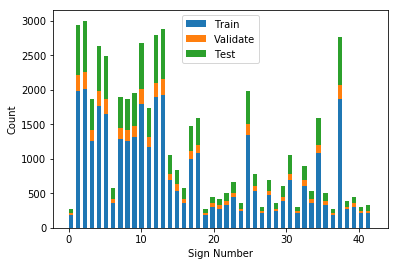

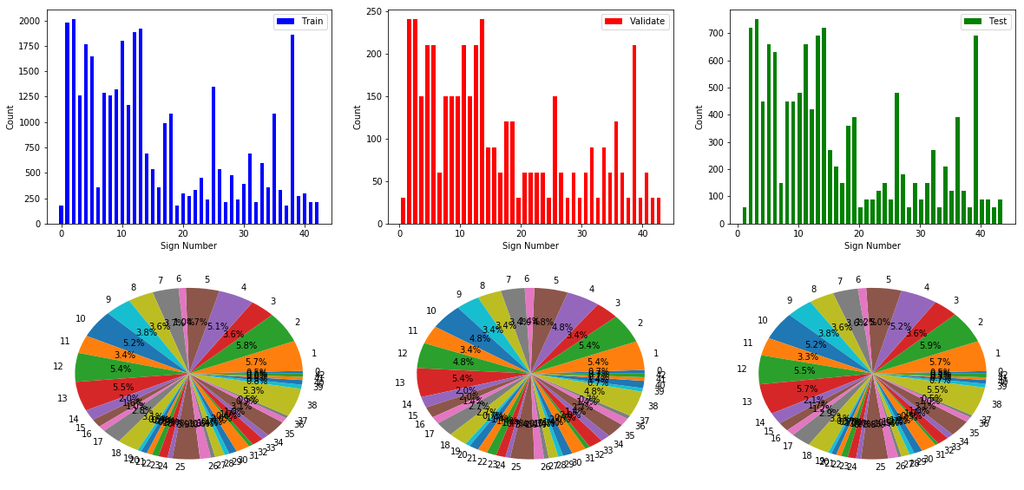

```python
from collections import Counter
import numpy as np

# setup chart layout
bins = 43 # 43 different types of signs
idx = np.arange(bins)
barWidth = 0.6

# plot histogram of all data sets
allLabels = [y_train,y_valid,y_test]

plt.hist(allLabels,bins=43,label=['Train','Validate','Test'], \
         histtype='barstacked',stacked=True, width=barWidth)
plt.xlabel('Sign Number')
plt.ylabel('Count')
plt.legend()

# get counts of each sign type per data set
trainCnt = Counter(y_train)
validCnt = Counter(y_valid)
testCnt = Counter(y_test)

# initialize the plot
figure, axes = plt.subplots(nrows=2,ncols=3,figsize=(20,10))



# get bars per data set
trainBars = axes[0][0].bar(idx, trainCnt.values(), width=barWidth, color='b', label='Train')
validBars = axes[0][1].bar(idx+barWidth, validCnt.values(), width=barWidth, color='r', label='Validate')
testBars = axes[0][2].bar(idx+barWidth*2, testCnt.values(), width=barWidth, color='g', label='Test')

# get pie charts per data set
trainPie = axes[1][0].pie(list(trainCnt.values()), labels=idx, autopct='%1.1f%%')
validPie = axes[1][1].pie(list(validCnt.values()), labels=idx, autopct='%1.1f%%')
testPie = axes[1][2].pie(list(testCnt.values()), labels=idx, autopct='%1.1f%%')


for ax in axes[0]:
    ax.set_xlabel('Sign Number')
    ax.set_ylabel('Count')
    ax.legend()

figure.show()
```

```python
### Data exploration visualization code goes here.
### Feel free to use as many code cells as needed.
import matplotlib.pyplot as plt
# Visualizations will be shown in the notebook.
%matplotlib inline

def rgb2Grey(rgbImage,weights=[1.0,1.0,1.0]):
    """simple multi-channel to 1 channel conversion"""
    grey = np.zeros((img.shape[0],img.shape[1]))
    for i in range(len(img)):
        for j in range(len(img[i])):
            grey[i][j] = np.average(img[i][j])
    return grey

def applyRGBThresholds(img,rgbThreshold=[0,0,0]):
    colorSelect = np.copy(img)
    imgThresholds = (img[:,:,0] < rgbThreshold[0]) \
                | (img[:,:,1] < rgbThreshold[1]) \
                | (img[:,:,2] < rgbThreshold[2])
    colorSelect[imgThresholds] = [0,0,0]

    return colorSelect

def applyGreyThresholds(img,thresholds=[0,255]):
    greySelect = np.copy(img)

    # lower bounds
    lowThresholds = (img[:,:] < thresholds[0])
    greySelect[lowThresholds] = 0

    # upper bounds
    highThresholds = (img[:,:] > thresholds[1])
    greySelect[highThresholds] = 255

    return greySelect

def imageViz(img,label=""):
    figure, axes = plt.subplots(nrows=3,ncols=4,figsize=(8,8))

    #show raw image
    figure.text(0,1,label)
    axes[0][0].imshow(img)

    # check image against each of the color channels
    #for i in range(1,4):
    #    axes[1][i].imshow(img[:,:,i-1],cmap=plt.cm.Greys_r)

    # rgb thresholding
    axes[0][1].imshow(applyRGBThresholds(img,rgbThreshold=[100,0,0]))
    axes[0][2].imshow(applyRGBThresholds(img,rgbThreshold=[0,100,0]))
    axes[0][3].imshow(applyRGBThresholds(img,rgbThreshold=[0,0,100]))

    # greyscale
    gImg = rgb2Grey(img)
    axes[1][0].imshow(gImg,cmap=plt.cm.Greys_r)

    # greyscale thresholding
    axes[1][1].imshow(applyGreyThresholds(gImg,thresholds=[10,80]),cmap=plt.cm.Greys_r)
    axes[1][2].imshow(applyGreyThresholds(gImg,thresholds=[20,100]),cmap=plt.cm.Greys_r)
    axes[1][3].imshow(applyGreyThresholds(gImg,thresholds=[30,200]),cmap=plt.cm.Greys_r)

    # greyscaled with ratio
    # (https://samarthbhargav.wordpress.com/2014/05/05/image-processing-with-python-rgb-to-grayscale-conversion/)
    # Green is the most prominent color (nearly 60%), followed by red(30%) and finally blue(11%).
    gImg = rgb2Grey(img, weights=[.299,.587,.114])
    axes[2][0].imshow(gImg,cmap=plt.cm.Greys_r)

    # greyscale thresholding
    axes[2][1].imshow(applyGreyThresholds(gImg,thresholds=[10,80]),cmap=plt.cm.Greys_r)
    axes[2][2].imshow(applyGreyThresholds(gImg,thresholds=[20,100]),cmap=plt.cm.Greys_r)
    axes[2][3].imshow(applyGreyThresholds(gImg,thresholds=[30,200]),cmap=plt.cm.Greys_r)

    figure.show()
```

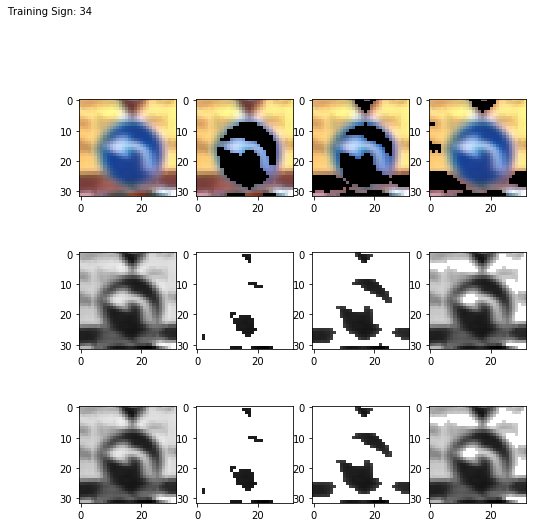

```python
import random

idx = random.randint(0,len(X_train))
img = X_train[idx].squeeze()
lbl = "Training Sign: {}".format(y_train[idx])

imageViz(img,lbl)
```

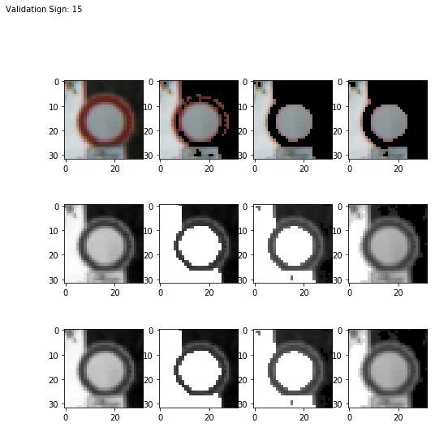

```python
import random

idx = random.randint(0,len(X_valid))
img = X_valid[idx].squeeze()
lbl = "Validation Sign: {}".format(y_valid[idx])

imageViz(img,lbl)
```

[figure not shown]

```python
import random

idx = random.randint(0,len(X_test))
img = X_test[idx].squeeze()
lbl = "Testing Sign: {}".format(y_test[idx])

imageViz(img,lbl)
```

## Step 2: Design and Test a Model Architecture

Design and implement a deep learning model that learns to recognize traffic signs. Train and test your model on the [German Traffic Sign Dataset](http://benchmark.ini.rub.de/?section=gtsrb&subsection=dataset).

The LeNet-5 implementation shown in the classroom at the end of the CNN lesson is a solid starting point. You'll have to change the number of classes and possibly the preprocessing, but aside from that it's plug and play!

With the LeNet-5 solution from the lecture, you should expect a validation set accuracy of about 0.89. To meet specifications, the validation set accuracy will need to be at least 0.93. It is possible to get an even higher accuracy, but 0.93 is the minimum for a successful project submission.

There are various aspects to consider when thinking about this problem:

- Neural network architecture (is the network over or underfitting?)
- Play around preprocessing techniques (normalization, rgb to grayscale, etc)
- Number of examples per label (some have more than others).
- Generate fake data.

Here is an example of a [published baseline model on this problem](http://yann.lecun.com/exdb/publis/pdf/sermanet-ijcnn-11.pdf). It's not required to be familiar with the approach used in the paper but, it's good practice to try to read papers like these.

### Pre-process the Data Set (normalization, grayscale, etc.)

Minimally, the image data should be normalized so that the data has mean zero and equal variance. For image data, `(pixel - 128)/ 128` is a quick way to approximately normalize the data and can be used in this project.

Other pre-processing steps are optional. You can try different techniques to see if it improves performance.

Use the code cell (or multiple code cells, if necessary) to implement the first step of your project.

```python
### Data exploration visualization code goes here.
### Feel free to use as many code cells as needed.
import matplotlib.pyplot as plt
# Visualizations will be shown in the notebook.
%matplotlib inline

### Preprocess the data here. It is required to normalize the data. Other preprocessing steps could include
### converting to grayscale, etc.
### Feel free to use as many code cells as needed.
def rgb2Grey(rgbImage,weights=[1.0,1.0,1.0]):
    """simple multi-channel to 1 channel conversion"""

    return np.dot(rgbImage[...,:3], weights)

def applyRGBThresholds(img,rgbThreshold=[0,0,0]):
    colorSelect = np.copy(img)
    imgThresholds = (img[:,:,0] < rgbThreshold[0]) \
                | (img[:,:,1] < rgbThreshold[1]) \
                | (img[:,:,2] < rgbThreshold[2])
    colorSelect[imgThresholds] = [0,0,0]

    return colorSelect

def applyGreyThresholds(img,thresholds=[0,255]):
    greySelect = np.copy(img)

    # lower bounds
    lowThresholds = (img[:,:] < thresholds[0])
    greySelect[lowThresholds] = 0

    # upper bounds
    highThresholds = (img[:,:] > thresholds[1])
    greySelect[highThresholds] = 255

    return greySelect

def imageViz(img,label=""):
    figure, axes = plt.subplots(nrows=3,ncols=4,figsize=(8,8))

    #show raw image
    figure.text(0,1,label)
    axes[0][0].imshow(img)

    # check image against each of the color channels
    #for i in range(1,4):
    #    axes[1][i].imshow(img[:,:,i-1],cmap=plt.cm.Greys_r)

    # rgb thresholding
    axes[0][1].imshow(applyRGBThresholds(img,rgbThreshold=[100,0,0]))
    axes[0][2].imshow(applyRGBThresholds(img,rgbThreshold=[0,100,0]))
    axes[0][3].imshow(applyRGBThresholds(img,rgbThreshold=[0,0,100]))

    # greyscale
    gImg = rgb2Grey(img)
    axes[1][0].imshow(gImg,cmap=plt.cm.Greys_r)

    # greyscale thresholding
    axes[1][1].imshow(applyGreyThresholds(gImg,thresholds=[10,80]),cmap=plt.cm.Greys_r)
    axes[1][2].imshow(applyGreyThresholds(gImg,thresholds=[20,100]),cmap=plt.cm.Greys_r)
    axes[1][3].imshow(applyGreyThresholds(gImg,thresholds=[30,200]),cmap=plt.cm.Greys_r)

    # greyscaled with ratio
    # (https://samarthbhargav.wordpress.com/2014/05/05/image-processing-with-python-rgb-to-grayscale-conversion/)
    # Green is the most prominent color (nearly 60%), followed by red(30%) and finally blue(11%).
    gImg = rgb2Grey(img, weights=[.299,.587,.114])
    axes[2][0].imshow(gImg,cmap=plt.cm.Greys_r)

    # greyscale thresholding
    axes[2][1].imshow(applyGreyThresholds(gImg,thresholds=[10,80]),cmap=plt.cm.Greys_r)
    axes[2][2].imshow(applyGreyThresholds(gImg,thresholds=[20,100]),cmap=plt.cm.Greys_r)
    axes[2][3].imshow(applyGreyThresholds(gImg,thresholds=[30,200]),cmap=plt.cm.Greys_r)

    figure.show()

def normalizeRGB(image):
    return (image[::] - 128.0) / 128.0

def normalizeGrey(image):
    return (image[::] - 128.0) / 128.0

def normalizeRGBGrey(image):
    return (image[::] - 128.0) / 128.0

def vizAccuracies(accuracies, title='', graphDim=(10,5)):

    figure, axes = plt.subplots(nrows=1,ncols=1,figsize=graphDim)
    axes.plot(accuracies)
    axes.set_xlabel('Epoch')
    axes.set_ylabel('Accuracy')
    axes.set_title(title)

    figure.show()
```

### Model Architecture

```python
### Define your architecture here.
### Feel free to use as many code cells as needed.
```

### Train, Validate and Test the Model

### Architecture

**Layer 1: Convolutional.** The output shape should be 28x28x6.

**Activation.** Your choice of activation function.

**Pooling.** The output shape should be 14x14x6.

**Layer 2: Convolutional.** The output shape should be 10x10x16.

**Activation.** Your choice of activation function.

**Pooling.** The output shape should be 5x5x16.

**Flatten.** Flatten the output shape of the final pooling layer such that it's 1D instead of 3D. The easiest way to do is by using `tf.contrib.layers.flatten`, which is already imported for you.

**Layer 3: Fully Connected.** This should have 120 outputs.

**Activation.** Your choice of activation function.

**Layer 4: Fully Connected.** This should have 84 outputs.

**Activation.** Your choice of activation function.

### Output

Return the result of the 2nd fully connected layer.

```python
def vgg16(image):
    mu = 0
    sigma = 0.1

    weights = {"c1":tf.Variable(tf.truncated_normal(shape=[3,3,3,64], mean=mu, stddev=sigma),name="c1"),
               "c2":tf.Variable(tf.truncated_normal(shape=[3,3,64,64], mean=mu, stddev=sigma),name="c2"),

               "c3":tf.Variable(tf.truncated_normal(shape=[3,3,64,128], mean=mu, stddev=sigma),name="c3"), #max pooling layer
               "c4":tf.Variable(tf.truncated_normal(shape=[3,3,128,128], mean=mu, stddev=sigma),name="c4"), #max pooling layer
               "c5":tf.Variable(tf.truncated_normal(shape=[3,3,128,128], mean=mu, stddev=sigma),name="c5"), #max pooling layer

               "c6":tf.Variable(tf.truncated_normal(shape=[3,3,128,256], mean=mu, stddev=sigma),name="c6"), #max pooling layer
               "c7":tf.Variable(tf.truncated_normal(shape=[3,3,256,256], mean=mu, stddev=sigma),name="c7"), #max pooling layer
               "c8":tf.Variable(tf.truncated_normal(shape=[8,8,256,256], mean=mu, stddev=sigma),name="c8"), #max pooling layer
               "c9":tf.Variable(tf.truncated_normal(shape=[8,8,256,256], mean=mu, stddev=sigma),name="c9"), #max pooling layer

               "c10":tf.Variable(tf.truncated_normal(shape=[3,3,256,512], mean=mu, stddev=sigma)), #max pooling layer
               "c11":tf.Variable(tf.truncated_normal(shape=[3,3,512,512], mean=mu, stddev=sigma)), #max pooling layer
               "c12":tf.Variable(tf.truncated_normal(shape=[3,3,512,512], mean=mu, stddev=sigma)), #max pooling layer
               "c13":tf.Variable(tf.truncated_normal(shape=[3,3,512,512], mean=mu, stddev=sigma)), #max pooling layer

               "c14":tf.Variable(tf.truncated_normal(shape=[2,2,512,512], mean=mu, stddev=sigma)), #max pooling layer
               "c15":tf.Variable(tf.truncated_normal(shape=[2,2,512,512], mean=mu, stddev=sigma)), #max pooling layer
               "c16":tf.Variable(tf.truncated_normal(shape=[2,2,512,512], mean=mu, stddev=sigma)), #max pooling layer
               "c17":tf.Variable(tf.truncated_normal(shape=[2,2,512,512], mean=mu, stddev=sigma)), #max pooling layer

               "c18":tf.Variable(tf.truncated_normal(shape=[2,2,512,512], mean=mu, stddev=sigma)), #max pooling layer

               "fc1":tf.Variable(tf.truncated_normal(shape=[1*1*512,120], mean=mu, stddev=sigma)),
               "fc2":tf.Variable(tf.truncated_normal(shape=[120,120], mean=mu, stddev=sigma)),
               "fc3":tf.Variable(tf.truncated_normal(shape=[120,84], mean=mu, stddev=sigma)),

               "logits":tf.Variable(tf.truncated_normal(shape=[84,43], mean=mu, stddev=sigma))
              }
    biases = {"c1":tf.Variable(tf.zeros(64)),
              "c2":tf.Variable(tf.zeros(64)),

              "c3":tf.Variable(tf.zeros(128)),
              "c4":tf.Variable(tf.zeros(128)),
              "c5":tf.Variable(tf.zeros(128)),

              "c6":tf.Variable(tf.zeros(256)),
              "c7":tf.Variable(tf.zeros(256)),
              "c8":tf.Variable(tf.zeros(256)),
              "c9":tf.Variable(tf.zeros(256)),

              "c10":tf.Variable(tf.zeros(512)),
              "c11":tf.Variable(tf.zeros(512)),
              "c12":tf.Variable(tf.zeros(512)),
              "c13":tf.Variable(tf.zeros(512)),

              "c14":tf.Variable(tf.zeros(512)),
              "c15":tf.Variable(tf.zeros(512)),
              "c16":tf.Variable(tf.zeros(512)),
              "c17":tf.Variable(tf.zeros(512)),


              "c18":tf.Variable(tf.zeros(512)),

              "fc1":tf.Variable(tf.zeros(120)),
              "fc2":tf.Variable(tf.zeros(120)),
              "fc3":tf.Variable(tf.zeros(84)),

              "logits":tf.Variable(tf.zeros(43))
             }

    # layer 1: Convolutional with output shape 32x32x64
    c1 = convLayer(inputValue=image, layerWeights=weights["c1"], layerBiases=biases["c1"],
                   layerPadding="SAME", layerName="c1")

    # layer 2: Convolutional with output shape 32x32x64
    c2 = convLayer(inputValue=c1, layerWeights=weights["c2"], layerBiases=biases["c2"],
                   layerPadding="SAME", layerName="c2")

    # layer 3: Convolutional max pooling with output shape 16x16x128
    c3 = convLayerWithMaxPool(inputValue=c2, layerWeights=weights["c3"], layerBiases=biases["c3"],
                              layerPadding="SAME", layerName="c3")

    # layer 4: Convolutional with output shape 16x16x128
    c4 = convLayer(inputValue=c3, layerWeights=weights["c4"], layerBiases=biases["c4"],
                   layerPadding="SAME", layerName="c4")

    # layer 5: Convolutional with output shape 16x16x128
    c5 = convLayer(inputValue=c4, layerWeights=weights["c5"], layerBiases=biases["c5"],
                   layerPadding="SAME", layerName="c5")

    # layer 6: Convolutional max pooling with output shape 8x8x256
    c6 = convLayerWithMaxPool(inputValue=c5, layerWeights=weights["c6"], layerBiases=biases["c6"],
                              layerPadding="SAME", layerName="c6")

    # layer 7: Convolutional with output shape 8x8x256
    c7 = convLayer(inputValue=c6, layerWeights=weights["c7"], layerBiases=biases["c7"],
                   layerPadding="SAME", layerName="c7")

    # layer 8: Convolutional with output shape 8x8x256
    c8 = convLayer(inputValue=c7, layerWeights=weights["c8"], layerBiases=biases["c8"],
                   layerPadding="SAME", layerName="c8")

    # layer 9: Convolutional with output shape 8x8x256
    c9 = convLayer(inputValue=c8, layerWeights=weights["c9"], layerBiases=biases["c9"],
                   layerPadding="SAME", layerName="c9")

    # layer 10: Convolutional max pooling with output shape 4x4x512
    c10 = convLayerWithMaxPool(inputValue=c9, layerWeights=weights["c10"], layerBiases=biases["c10"],
                               layerPadding="SAME", layerName="c10")

    # layer 11: Convolutional with output shape 4x4x512
    c11 = convLayer(inputValue=c10, layerWeights=weights["c11"], layerBiases=biases["c11"],
                    layerPadding="SAME", layerName="c11")

    # layer 12: Convolutional with output shape 4x4x512
    c12 = convLayer(inputValue=c11, layerWeights=weights["c12"], layerBiases=biases["c12"],
                    layerPadding="SAME", layerName="c12")

    # layer 13: Convolutional with output shape 4x4x512
    c13 = convLayerWithMaxPool(inputValue=c12, layerWeights=weights["c13"], layerBiases=biases["c13"],
                               layerPadding="SAME", layerName="c13")

    # layer 14: Convolutional max pooling with output shape 2x2x512
    c14 = convLayerWithMaxPool(inputValue=c13, layerWeights=weights["c14"], layerBiases=biases["c14"],
                               layerPadding="SAME", layerName="c14")


    # layer 15: Convolutional with output shape 2x2x512
    c15 = convLayer(inputValue=c14, layerWeights=weights["c15"], layerBiases=biases["c15"],
                    layerPadding="SAME", layerName="c15")

    # layer 16: Convolutional with output shape 2x2x512
    c16 = convLayer(inputValue=c15, layerWeights=weights["c16"], layerBiases=biases["c16"],
                    layerPadding="SAME", layerName="c16")

    # layer 17: Convolutional max pooling with output shape 2x2x512
    c17 = convLayer(inputValue=c16, layerWeights=weights["c17"], layerBiases=biases["c17"],
                    layerPadding="SAME", layerName="c17")

    # layer 18: Convolutional max pooling with output shape 1x1x512
    c18 = convLayerWithMaxPool(inputValue=c17, layerWeights=weights["c18"], layerBiases=biases["c18"],
                               layerPadding="SAME", layerName="c18")

    # flatten layer for fully connected layer
    f = flatten(c18)
    #print(f)#.shape)

    # layer 19: Fully Connected
    fc1 = fullLayer(inputValue=f, layerWeights=weights["fc1"], layerBiases=biases["fc1"], layerName="fc1")

    # layer 20: Fully Connected
    fc2 = fullLayer(inputValue=fc1, layerWeights=weights["fc2"], layerBiases=biases["fc2"], layerName="fc2")

    # layer 21: Fully Connected
    fc3 = fullLayer(inputValue=fc2, layerWeights=weights["fc3"], layerBiases=biases["fc3"], layerName="fc3")

    # layer 22
    return tf.add(tf.matmul(fc3,weights["logits"]),biases["logits"])
```

```python
import tensorflow as tf
from tensorflow.contrib.layers import flatten
import numpy as np

def convLayer(inputValue, layerWeights, layerBiases, layerName, convStrides=[1,1,1,1], layerPadding="VALID"):
    '''
    Creates a convolutional layer with:
        (i) Convolution with stride
        (ii) Activation function (ReLU)
    '''

    c = tf.nn.conv2d(input=inputValue, filter=layerWeights, strides=convStrides, padding=layerPadding)
    c = tf.nn.bias_add(value=c, bias=layerBiases)
    c = tf.nn.relu(c)

    return tf.nn.relu(c,name=layerName)

def convLayerWithMaxPool(inputValue, layerWeights, layerBiases, layerName, convStrides=[1,1,1,1], layerPadding="VALID",\
              poolingSize=[1,2,2,1], poolingStride=[1,2,2,1]):
    '''
    Creates a convolutional layer with:
        (i) Convolution with stride
        (ii) Activation function (ReLU)
        (iii) Pooling
    '''

    c = convLayer(inputValue, layerWeights, layerBiases, layerName+'_0', convStrides, layerPadding)

    return tf.nn.max_pool(value=c, ksize=poolingSize, strides=poolingStride, padding=layerPadding, name=layerName)

def fullLayer(inputValue, layerWeights, layerBiases, layerName):
    '''
    Creates a fully connected layer with:
    (i) (W*x)+b
    (ii) Activation function (ReLU)
    '''
    f = tf.add(tf.matmul(inputValue,layerWeights), layerBiases)

    return tf.nn.relu(f, name=layerName)

def leNet(image):
    mu = 0
    sigma = 0.1

    weights = {"c1":tf.Variable(tf.truncated_normal(shape=[5,5,3,6], mean=mu, stddev=sigma)),
               "c2":tf.Variable(tf.truncated_normal(shape=[5,5,6,16], mean=mu, stddev=sigma)),
               "fc1":tf.Variable(tf.truncated_normal(shape=[5*5*16,120], mean=mu, stddev=sigma)),
               "fc2":tf.Variable(tf.truncated_normal(shape=[120,84], mean=mu, stddev=sigma)),
               "logits":tf.Variable(tf.truncated_normal(shape=[84,43], mean=mu, stddev=sigma))
              }
    biases = {"c1":tf.Variable(tf.zeros(6)),
              "c2":tf.Variable(tf.zeros(16)),
              "fc1":tf.Variable(tf.zeros(120)),
              "fc2":tf.Variable(tf.zeros(84)),
              "logits":tf.Variable(tf.zeros(43))
             }

    # layer 1: Convolutional with output shape 28x28x6
    c1 = convLayerWithMaxPool(inputValue=image, layerWeights=weights["c1"], layerBiases=biases["c1"], layerName="c1")

    # layer 2: Convolutional with output shape 14x14x16
    c2 = convLayerWithMaxPool(inputValue=c1, layerWeights=weights["c2"], layerBiases=biases["c2"], layerName="c2")

    # flatten layer for fully connected layer
    f = flatten(c2)
    #print(f)#.shape)

    # layer 3: Fully Connected
    fc1 = fullLayer(inputValue=f, layerWeights=weights["fc1"], layerBiases=biases["fc1"], layerName="fc1")

    # layer 4: Fully Connected
    fc2 = fullLayer(inputValue=fc1, layerWeights=weights["fc2"], layerBiases=biases["fc2"], layerName="fc2")

    # layer 5
    return tf.add(tf.matmul(fc2,weights["logits"]),biases["logits"])


def myNet(image, weights, biases, dropProb):

    ### GROUP 1
    # layer 1: Convolutional with output shape 32x32x8
    c1 = convLayer(inputValue=image, layerWeights=weights["c1"], layerBiases=biases["c1"],
                              layerPadding="SAME", layerName="c1")
    c1 = tf.nn.dropout(c1, dropProb)

    # layer 2: Convolutional with output shape 32x32x16
    c2 = convLayer(inputValue=c1, layerWeights=weights["c2"], layerBiases=biases["c2"],
                              layerPadding="SAME", layerName="c2")
    c2 = tf.nn.dropout(c2, dropProb)



    ### GROUP 2
    # layer 3: Convolutional (max pooling) with output shape 16x16x16
    c3 = convLayerWithMaxPool(inputValue=c2, layerWeights=weights["c3"], layerBiases=biases["c3"],
                              layerPadding="SAME", layerName="c3")
    c3 = tf.nn.dropout(c3, dropProb)

    # layer 4: Convolutional with output shape 16x16x16
    c4 = convLayer(inputValue=c3, layerWeights=weights["c4"], layerBiases=biases["c4"],
                            layerPadding="SAME", layerName="c4")
    c4 = tf.nn.dropout(c4, dropProb)

    # layer 5: Convolutional with output shape 32x32x16
    c5 = convLayer(inputValue=c4, layerWeights=weights["c5"], layerBiases=biases["c5"],
                              layerPadding="SAME", layerName="c5")
    c5 = tf.nn.dropout(c5, dropProb)



    ### GROUP 3
    # layer 6: Convolutional (max pooling) with output shape 8x8x32
    c6 = convLayerWithMaxPool(inputValue=c5, layerWeights=weights["c6"], layerBiases=biases["c6"],
                              layerPadding="SAME", layerName="c6")
    c6 = tf.nn.dropout(c6, dropProb)

    # layer 7: Convolutional with output shape 8x8x32
    c7 = convLayer(inputValue=c6, layerWeights=weights["c7"], layerBiases=biases["c7"],
                              layerPadding="SAME", layerName="c7")
    c7 = tf.nn.dropout(c7, dropProb)

    # layer 8: Convolutional with output shape 8x8x32
    c8 = convLayerWithMaxPool(inputValue=c7, layerWeights=weights["c8"], layerBiases=biases["c8"],
                              layerPadding="SAME", layerName="c8")
    c8 = tf.nn.dropout(c8, dropProb)



    # flatten layer for fully connected layer
    f = flatten(c8)
    #print(f)#.shape)



    ### GROUP 4
    # layer 9: Fully Connected
    fc1 = fullLayer(inputValue=f, layerWeights=weights["fc1"], layerBiases=biases["fc1"], layerName="fc1")
    fc1 = tf.nn.dropout(fc1, dropProb)

    # layer 10: Fully Connected
    fc2 = fullLayer(inputValue=fc1, layerWeights=weights["fc2"], layerBiases=biases["fc2"], layerName="fc2")
    fc2 = tf.nn.dropout(fc2, dropProb)

    # layer 11: Fully Connected
    fc3 = fullLayer(inputValue=fc2, layerWeights=weights["fc3"], layerBiases=biases["fc3"], layerName="fc3")
    fc3 = tf.nn.dropout(fc3, dropProb)



    ### OUTPUT
    # layer 12
    return tf.add(tf.matmul(fc3,weights["logits"]),biases["logits"], name="output")



def myRGBNet(image, dropProb):
    mu = 0
    sigma = 0.1

    weights = {"c1":tf.Variable(tf.truncated_normal(shape=[5,5,3,8], mean=mu, stddev=sigma)),
               "c2":tf.Variable(tf.truncated_normal(shape=[5,5,8,8], mean=mu, stddev=sigma)),

               "c3":tf.Variable(tf.truncated_normal(shape=[5,5,8,16], mean=mu, stddev=sigma)),
               "c4":tf.Variable(tf.truncated_normal(shape=[5,5,16,16], mean=mu, stddev=sigma)),
               "c5":tf.Variable(tf.truncated_normal(shape=[5,5,16,16], mean=mu, stddev=sigma)),

               "c6":tf.Variable(tf.truncated_normal(shape=[5,5,16,32], mean=mu, stddev=sigma)),
               "c7":tf.Variable(tf.truncated_normal(shape=[5,5,32,32], mean=mu, stddev=sigma)),

               "c8":tf.Variable(tf.truncated_normal(shape=[5,5,32,64], mean=mu, stddev=sigma)),

               "fc1":tf.Variable(tf.truncated_normal(shape=[4*4*64,120], mean=mu, stddev=sigma)),
               "fc2":tf.Variable(tf.truncated_normal(shape=[120,84], mean=mu, stddev=sigma)),
               "fc3":tf.Variable(tf.truncated_normal(shape=[84,84], mean=mu, stddev=sigma)),
               "logits":tf.Variable(tf.truncated_normal(shape=[84,43], mean=mu, stddev=sigma))
              }
    biases = {"c1":tf.Variable(tf.zeros(8)),
              "c2":tf.Variable(tf.zeros(8)),

              "c3":tf.Variable(tf.zeros(16)),
              "c4":tf.Variable(tf.zeros(16)),
              "c5":tf.Variable(tf.zeros(16)),

              "c6":tf.Variable(tf.zeros(32)),
              "c7":tf.Variable(tf.zeros(32)),

              "c8":tf.Variable(tf.zeros(64)),

              "fc1":tf.Variable(tf.zeros(120)),
              "fc2":tf.Variable(tf.zeros(84)),
              "fc3":tf.Variable(tf.zeros(84)),
              "logits":tf.Variable(tf.zeros(43))
             }

    return myNet(image, weights, biases, dropProb)

def myGreyNet(image, dropProb):
    mu = 0
    sigma = 0.1

    weights = {"c1":tf.Variable(tf.truncated_normal(shape=[5,5,1,8], mean=mu, stddev=sigma)),
               "c2":tf.Variable(tf.truncated_normal(shape=[5,5,8,8], mean=mu, stddev=sigma)),

               "c3":tf.Variable(tf.truncated_normal(shape=[5,5,8,16], mean=mu, stddev=sigma)),
               "c4":tf.Variable(tf.truncated_normal(shape=[5,5,16,16], mean=mu, stddev=sigma)),
               "c5":tf.Variable(tf.truncated_normal(shape=[5,5,16,16], mean=mu, stddev=sigma)),

               "c6":tf.Variable(tf.truncated_normal(shape=[5,5,16,32], mean=mu, stddev=sigma)),
               "c7":tf.Variable(tf.truncated_normal(shape=[5,5,32,32], mean=mu, stddev=sigma)),

               "c8":tf.Variable(tf.truncated_normal(shape=[5,5,32,64], mean=mu, stddev=sigma)),

               "fc1":tf.Variable(tf.truncated_normal(shape=[4*4*64,120], mean=mu, stddev=sigma)),
               "fc2":tf.Variable(tf.truncated_normal(shape=[120,84], mean=mu, stddev=sigma)),
               "fc3":tf.Variable(tf.truncated_normal(shape=[84,84], mean=mu, stddev=sigma)),
               "logits":tf.Variable(tf.truncated_normal(shape=[84,43], mean=mu, stddev=sigma))
              }
    biases = {"c1":tf.Variable(tf.zeros(8)),
              "c2":tf.Variable(tf.zeros(8)),

              "c3":tf.Variable(tf.zeros(16)),
              "c4":tf.Variable(tf.zeros(16)),
              "c5":tf.Variable(tf.zeros(16)),

              "c6":tf.Variable(tf.zeros(32)),
              "c7":tf.Variable(tf.zeros(32)),

              "c8":tf.Variable(tf.zeros(64)),

              "fc1":tf.Variable(tf.zeros(120)),
              "fc2":tf.Variable(tf.zeros(84)),
              "fc3":tf.Variable(tf.zeros(84)),
              "logits":tf.Variable(tf.zeros(43))
             }

    return myNet(image, weights, biases, dropProb)


def myRGBGreyNet(image, dropProb):
    mu = 0
    sigma = 0.1

    weights = {"c1":tf.Variable(tf.truncated_normal(shape=[5,5,4,8], mean=mu, stddev=sigma)),
               "c2":tf.Variable(tf.truncated_normal(shape=[5,5,8,8], mean=mu, stddev=sigma)),

               "c3":tf.Variable(tf.truncated_normal(shape=[5,5,8,16], mean=mu, stddev=sigma)),
               "c4":tf.Variable(tf.truncated_normal(shape=[5,5,16,16], mean=mu, stddev=sigma)),
               "c5":tf.Variable(tf.truncated_normal(shape=[5,5,16,16], mean=mu, stddev=sigma)),

               "c6":tf.Variable(tf.truncated_normal(shape=[5,5,16,32], mean=mu, stddev=sigma)),
               "c7":tf.Variable(tf.truncated_normal(shape=[5,5,32,32], mean=mu, stddev=sigma)),

               "c8":tf.Variable(tf.truncated_normal(shape=[5,5,32,64], mean=mu, stddev=sigma)),

               "fc1":tf.Variable(tf.truncated_normal(shape=[4*4*64,120], mean=mu, stddev=sigma)),
               "fc2":tf.Variable(tf.truncated_normal(shape=[120,84], mean=mu, stddev=sigma)),
               "fc3":tf.Variable(tf.truncated_normal(shape=[84,84], mean=mu, stddev=sigma)),
               "logits":tf.Variable(tf.truncated_normal(shape=[84,43], mean=mu, stddev=sigma))
              }
    biases = {"c1":tf.Variable(tf.zeros(8)),
              "c2":tf.Variable(tf.zeros(8)),

              "c3":tf.Variable(tf.zeros(16)),
              "c4":tf.Variable(tf.zeros(16)),
              "c5":tf.Variable(tf.zeros(16)),

              "c6":tf.Variable(tf.zeros(32)),
              "c7":tf.Variable(tf.zeros(32)),

              "c8":tf.Variable(tf.zeros(64)),

              "fc1":tf.Variable(tf.zeros(120)),
              "fc2":tf.Variable(tf.zeros(84)),
              "fc3":tf.Variable(tf.zeros(84)),
              "logits":tf.Variable(tf.zeros(43))
             }

    return myNet(image, weights, biases, dropProb)
```

A validation set can be used to assess how well the model is performing. A low accuracy on the training and validation sets imply underfitting. A high accuracy on the training set but low accuracy on the validation set implies overfitting.

```python
### Train your model here.
### Calculate and report the accuracy on the training and validation set.
### Once a final model architecture is selected,
### the accuracy on the test set should be calculated and reported as well.
### Feel free to use as many code cells as needed.
```

```python
## evaluate the accuracy of the network
def evaluate(X_data, y_data, batchSize, channelCnt=3, drop_prob=1.0):
    num_examples = len(X_data)
    total_accuracy = 0
    sess = tf.get_default_session()
    for offset in range(0, num_examples, batchSize):
        batch_x, batch_y = X_data[offset:offset+batchSize], y_data[offset:offset+batchSize]
        dimensions = batch_x.shape
        batch_x = batch_x.reshape((dimensions[0],dimensions[1],dimensions[2],channelCnt))

        accuracy = sess.run(accuracyOperation, feed_dict={images: batch_x, labels: batch_y, dropProb: drop_prob})
        total_accuracy += (accuracy * len(batch_x))
    return total_accuracy / num_examples
```

### Try RGB

#### 10 Epochs & 0.001 Learn Rate & 100% [not]Drop Probability (likely to be in the network)

```
Training...

EPOCH 0 ... Validation Accuracy: 0.791
EPOCH 1 ... Validation Accuracy: 0.894
EPOCH 2 ... Validation Accuracy: 0.912
EPOCH 3 ... Validation Accuracy: 0.908
EPOCH 4 ... Validation Accuracy: 0.911
EPOCH 5 ... Validation Accuracy: 0.931
EPOCH 6 ... Validation Accuracy: 0.929
EPOCH 7 ... Validation Accuracy: 0.934
EPOCH 8 ... Validation Accuracy: 0.918
EPOCH 9 ... Validation Accuracy: 0.931

FINAL EPOCH 9 ... Validation Accuracy: 0.931
Model saved

Testing Model
TEST ACCURACY: 0.924
```

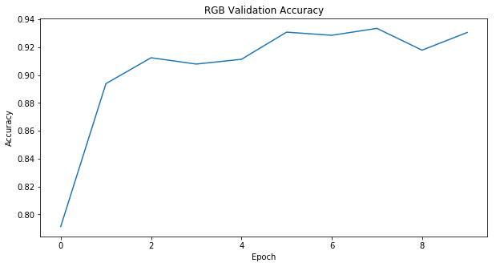

```python
from sklearn.utils import shuffle
import pickle


# Global settings to be used across each implementation
EPOCHS = 10
BATCH_SIZE = 128
LEARN_RATE = 0.001
DROP_PROB = 1.0

outputFrequency = 1



# Get the training data
training_file = 'data/train.p'
validation_file= 'data/valid.p'
testing_file = 'data/test.p'

with open(training_file, mode='rb') as f:
    train = pickle.load(f)
with open(validation_file, mode='rb') as f:
    valid = pickle.load(f)
with open(testing_file, mode='rb') as f:
    test = pickle.load(f)

X_train, y_train = train['features'], train['labels']
X_valid, y_valid = valid['features'], valid['labels']
X_test, y_test = test['features'], test['labels']



# Get the images and labels
images = tf.placeholder(tf.float32,(None,32,32,3))
labels  = tf.placeholder(tf.int32,(None))
oneHotLabels = tf.one_hot(labels,43)
dropProb = tf.placeholder(tf.float32) # probability of keeping a node in

# Normalize the images - zero mean
X_train = np.array([np.array(normalizeRGB(img)) for img in X_train])
X_valid = np.array([np.array(normalizeRGB(img)) for img in X_valid])
X_test = np.array([np.array(normalizeRGB(img)) for img in X_test])



accuracies = list()

logits = myRGBNet(images,DROP_PROB)#vgg16(images)#leNet(images)
crossEntropy = tf.nn.softmax_cross_entropy_with_logits(labels=oneHotLabels, logits=logits)
lossOperation = tf.reduce_mean(crossEntropy)
optimizer = tf.train.AdamOptimizer(learning_rate=LEARN_RATE)
trainingOperation = optimizer.minimize(lossOperation)
correctPrediction = tf.equal(tf.argmax(logits, 1), tf.argmax(oneHotLabels, 1))
accuracyOperation = tf.reduce_mean(tf.cast(correctPrediction, tf.float32))
saver = tf.train.Saver()

# Run the network
with tf.Session() as sess:
    sess.run(tf.global_variables_initializer())
    num_examples = len(X_train)

    print("Training...")
    print()
    for i in range(EPOCHS):
        X_train, y_train = shuffle(X_train, y_train) # shuffle the training data to get a random selection per batch

        for offset in range(0, num_examples, BATCH_SIZE):
            end = offset + BATCH_SIZE
            batch_x, batch_y = X_train[offset:end], y_train[offset:end] # get BATCH_SIZE (i.e. 128) records to processes


            # Run the training on the batch
            sess.run(trainingOperation, feed_dict={images: batch_x, labels: batch_y, dropProb: DROP_PROB})

        # Validate the model
        validation_accuracy = evaluate(X_valid, y_valid, batchSize=BATCH_SIZE, channelCnt=3)
        accuracies.append(validation_accuracy)

        if (i)%outputFrequency == 0:
            print("EPOCH {} ... Validation Accuracy: {:.3f}".format(i, validation_accuracy))

    print("\nFINAL EPOCH {} ... Validation Accuracy: {:.3f}".format(i, validation_accuracy))

    saver.save(sess, './rgbNet_10_001_100.ckpt')
    print("Model saved")

    print("\nTesting Model")
    test_accuracy = sess.run(accuracyOperation, feed_dict={images: X_test, labels: y_test, dropProb: 1.0})
    print("TEST ACCURACY: {:.3f}".format(test_accuracy))

# Display chart of accuracy per epoch
vizAccuracies(accuracies,title='RGB Validation Accuracy')
```

#### 10 Epochs & 0.001 Learn Rate & 50% [not]Drop Probability (likely to be in the network)

```
Training...

EPOCH 0 ... Validation Accuracy: 0.052
EPOCH 1 ... Validation Accuracy: 0.051
EPOCH 2 ... Validation Accuracy: 0.057
EPOCH 3 ... Validation Accuracy: 0.052
EPOCH 4 ... Validation Accuracy: 0.058
EPOCH 5 ... Validation Accuracy: 0.065
EPOCH 6 ... Validation Accuracy: 0.064
EPOCH 7 ... Validation Accuracy: 0.083
EPOCH 8 ... Validation Accuracy: 0.097
EPOCH 9 ... Validation Accuracy: 0.105

FINAL EPOCH 9 ... Validation Accuracy: 0.105
Model saved

Testing Model
TEST ACCURACY: 0.111
```

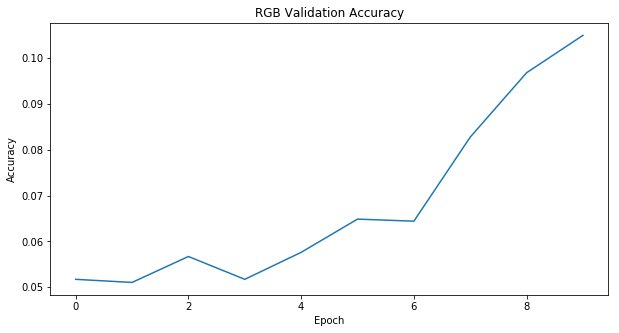

```python
from sklearn.utils import shuffle
import pickle


# Global settings to be used across each implementation
EPOCHS = 10
BATCH_SIZE = 128
LEARN_RATE = 0.001
DROP_PROB = 0.50

outputFrequency = 1



# Get the training data
training_file = 'data/train.p'
validation_file= 'data/valid.p'
testing_file = 'data/test.p'

with open(training_file, mode='rb') as f:
    train = pickle.load(f)
with open(validation_file, mode='rb') as f:
    valid = pickle.load(f)
with open(testing_file, mode='rb') as f:
    test = pickle.load(f)

X_train, y_train = train['features'], train['labels']
X_valid, y_valid = valid['features'], valid['labels']
X_test, y_test = test['features'], test['labels']



# Get the images and labels
images = tf.placeholder(tf.float32,(None,32,32,3))
labels  = tf.placeholder(tf.int32,(None))
oneHotLabels = tf.one_hot(labels,43)
dropProb = tf.placeholder(tf.float32) # probability of keeping a node in

# Normalize the images - zero mean
X_train = np.array([np.array(normalizeRGB(img)) for img in X_train])
X_valid = np.array([np.array(normalizeRGB(img)) for img in X_valid])
X_test = np.array([np.array(normalizeRGB(img)) for img in X_test])



accuracies = list()

logits = myRGBNet(images,DROP_PROB)#vgg16(images)#leNet(images)
crossEntropy = tf.nn.softmax_cross_entropy_with_logits(labels=oneHotLabels, logits=logits)
lossOperation = tf.reduce_mean(crossEntropy)
optimizer = tf.train.AdamOptimizer(learning_rate=LEARN_RATE)
trainingOperation = optimizer.minimize(lossOperation)
correctPrediction = tf.equal(tf.argmax(logits, 1), tf.argmax(oneHotLabels, 1))
accuracyOperation = tf.reduce_mean(tf.cast(correctPrediction, tf.float32))
saver = tf.train.Saver()

# Run the network
with tf.Session() as sess:
    sess.run(tf.global_variables_initializer())
    num_examples = len(X_train)

    print("Training...")
    print()
    for i in range(EPOCHS):
        X_train, y_train = shuffle(X_train, y_train) # shuffle the training data to get a random selection per batch

        for offset in range(0, num_examples, BATCH_SIZE):
            end = offset + BATCH_SIZE
            batch_x, batch_y = X_train[offset:end], y_train[offset:end] # get BATCH_SIZE (i.e. 128) records to processes


            # Run the training on the batch
            sess.run(trainingOperation, feed_dict={images: batch_x, labels: batch_y, dropProb: DROP_PROB})

        # Validate the model
        validation_accuracy = evaluate(X_valid, y_valid, batchSize=BATCH_SIZE, channelCnt=3)
        accuracies.append(validation_accuracy)

        if (i)%outputFrequency == 0:
            print("EPOCH {} ... Validation Accuracy: {:.3f}".format(i, validation_accuracy))

    print("\nFINAL EPOCH {} ... Validation Accuracy: {:.3f}".format(i, validation_accuracy))

    saver.save(sess, './rgbNet_10_001_50.ckpt')
    print("Model saved")

    print("\nTesting Model")
    test_accuracy = sess.run(accuracyOperation, feed_dict={images: X_test, labels: y_test, dropProb: 1.0})
    print("TEST ACCURACY: {:.3f}".format(test_accuracy))

# Display chart of accuracy per epoch
vizAccuracies(accuracies,title='RGB Validation Accuracy')
```

#### 10 Epochs & 0.001 Learn Rate & 75% [not]Drop Probability (likely to be in the network)

```
Training...

EPOCH 0 ... Validation Accuracy: 0.051
EPOCH 1 ... Validation Accuracy: 0.105
EPOCH 2 ... Validation Accuracy: 0.299
EPOCH 3 ... Validation Accuracy: 0.309
EPOCH 4 ... Validation Accuracy: 0.332
EPOCH 5 ... Validation Accuracy: 0.369
EPOCH 6 ... Validation Accuracy: 0.406
EPOCH 7 ... Validation Accuracy: 0.460
EPOCH 8 ... Validation Accuracy: 0.499
EPOCH 9 ... Validation Accuracy: 0.552

FINAL EPOCH 9 ... Validation Accuracy: 0.552
Model saved

Testing Model
TEST ACCURACY: 0.569
```

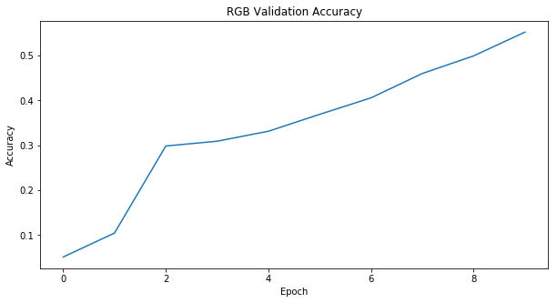

```python
from sklearn.utils import shuffle
import pickle


# Global settings to be used across each implementation
EPOCHS = 10
BATCH_SIZE = 128
LEARN_RATE = 0.001
DROP_PROB = 0.75

outputFrequency = 1



# Get the training data
training_file = 'data/train.p'
validation_file= 'data/valid.p'
testing_file = 'data/test.p'

with open(training_file, mode='rb') as f:
    train = pickle.load(f)
with open(validation_file, mode='rb') as f:
    valid = pickle.load(f)
with open(testing_file, mode='rb') as f:
    test = pickle.load(f)

X_train, y_train = train['features'], train['labels']
X_valid, y_valid = valid['features'], valid['labels']
X_test, y_test = test['features'], test['labels']



# Get the images and labels
images = tf.placeholder(tf.float32,(None,32,32,3))
labels  = tf.placeholder(tf.int32,(None))
oneHotLabels = tf.one_hot(labels,43)
dropProb = tf.placeholder(tf.float32) # probability of keeping a node in

# Normalize the images - zero mean
X_train = np.array([np.array(normalizeRGB(img)) for img in X_train])
X_valid = np.array([np.array(normalizeRGB(img)) for img in X_valid])
X_test = np.array([np.array(normalizeRGB(img)) for img in X_test])



accuracies = list()

logits = myRGBNet(images,DROP_PROB)#vgg16(images)#leNet(images)
crossEntropy = tf.nn.softmax_cross_entropy_with_logits(labels=oneHotLabels, logits=logits)
lossOperation = tf.reduce_mean(crossEntropy)
optimizer = tf.train.AdamOptimizer(learning_rate=LEARN_RATE)
trainingOperation = optimizer.minimize(lossOperation)
correctPrediction = tf.equal(tf.argmax(logits, 1), tf.argmax(oneHotLabels, 1))
accuracyOperation = tf.reduce_mean(tf.cast(correctPrediction, tf.float32))
saver = tf.train.Saver()

# Run the network
with tf.Session() as sess:
    sess.run(tf.global_variables_initializer())
    num_examples = len(X_train)

    print("Training...")
    print()
    for i in range(EPOCHS):
        X_train, y_train = shuffle(X_train, y_train) # shuffle the training data to get a random selection per batch

        for offset in range(0, num_examples, BATCH_SIZE):
            end = offset + BATCH_SIZE
            batch_x, batch_y = X_train[offset:end], y_train[offset:end] # get BATCH_SIZE (i.e. 128) records to processes


            # Run the training on the batch
            sess.run(trainingOperation, feed_dict={images: batch_x, labels: batch_y, dropProb: DROP_PROB})

        # Validate the model
        validation_accuracy = evaluate(X_valid, y_valid, batchSize=BATCH_SIZE, channelCnt=3)
        accuracies.append(validation_accuracy)

        if (i)%outputFrequency == 0:
            print("EPOCH {} ... Validation Accuracy: {:.3f}".format(i, validation_accuracy))

    print("\nFINAL EPOCH {} ... Validation Accuracy: {:.3f}".format(i, validation_accuracy))

    saver.save(sess, './rgbNet_10_001_75.ckpt')
    print("Model saved")

    print("\nTesting Model")
    test_accuracy = sess.run(accuracyOperation, feed_dict={images: X_test, labels: y_test, dropProb: 1.0})
    print("TEST ACCURACY: {:.3f}".format(test_accuracy))

# Display chart of accuracy per epoch
vizAccuracies(accuracies,title='RGB Validation Accuracy')
```

#### 100 Epochs & 0.001 Learn Rate & 100% [not]Drop Probability (likely to be in the network)

```
Training...

EPOCH 0 ... Validation Accuracy: 0.809
EPOCH 10 ... Validation Accuracy: 0.920
EPOCH 20 ... Validation Accuracy: 0.939
EPOCH 30 ... Validation Accuracy: 0.938
EPOCH 40 ... Validation Accuracy: 0.943
EPOCH 50 ... Validation Accuracy: 0.932
EPOCH 60 ... Validation Accuracy: 0.956
EPOCH 70 ... Validation Accuracy: 0.949
EPOCH 80 ... Validation Accuracy: 0.949
EPOCH 90 ... Validation Accuracy: 0.942

FINAL EPOCH 99 ... Validation Accuracy: 0.958
Model saved

Testing Model
TEST ACCURACY: 0.943
```

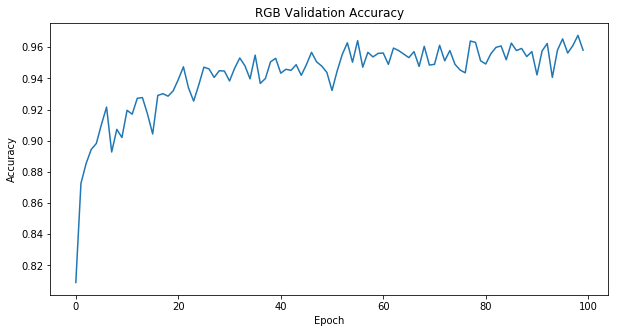

```python
from sklearn.utils import shuffle
import pickle


# Global settings to be used across each implementation
EPOCHS = 100
BATCH_SIZE = 128
LEARN_RATE = 0.001
DROP_PROB = 1.00

outputFrequency = 10



# Get the training data
training_file = 'data/train.p'
validation_file= 'data/valid.p'
testing_file = 'data/test.p'

with open(training_file, mode='rb') as f:
    train = pickle.load(f)
with open(validation_file, mode='rb') as f:
    valid = pickle.load(f)
with open(testing_file, mode='rb') as f:
    test = pickle.load(f)

X_train, y_train = train['features'], train['labels']
X_valid, y_valid = valid['features'], valid['labels']
X_test, y_test = test['features'], test['labels']



# Get the images and labels
images = tf.placeholder(tf.float32,(None,32,32,3))
labels  = tf.placeholder(tf.int32,(None))
oneHotLabels = tf.one_hot(labels,43)
dropProb = tf.placeholder(tf.float32) # probability of keeping a node in

# Normalize the images - zero mean
X_train = np.array([np.array(normalizeRGB(img)) for img in X_train])
X_valid = np.array([np.array(normalizeRGB(img)) for img in X_valid])
X_test = np.array([np.array(normalizeRGB(img)) for img in X_test])



accuracies = list()

logits = myRGBNet(images,DROP_PROB)#vgg16(images)#leNet(images)
crossEntropy = tf.nn.softmax_cross_entropy_with_logits(labels=oneHotLabels, logits=logits)
lossOperation = tf.reduce_mean(crossEntropy)
optimizer = tf.train.AdamOptimizer(learning_rate=LEARN_RATE)
trainingOperation = optimizer.minimize(lossOperation)
correctPrediction = tf.equal(tf.argmax(logits, 1), tf.argmax(oneHotLabels, 1))
accuracyOperation = tf.reduce_mean(tf.cast(correctPrediction, tf.float32))
saver = tf.train.Saver()

# Run the network
with tf.Session() as sess:
    sess.run(tf.global_variables_initializer())
    num_examples = len(X_train)

    print("Training...")
    print()
    for i in range(EPOCHS):
        X_train, y_train = shuffle(X_train, y_train) # shuffle the training data to get a random selection per batch

        for offset in range(0, num_examples, BATCH_SIZE):
            end = offset + BATCH_SIZE
            batch_x, batch_y = X_train[offset:end], y_train[offset:end] # get BATCH_SIZE (i.e. 128) records to processes


            # Run the training on the batch
            sess.run(trainingOperation, feed_dict={images: batch_x, labels: batch_y, dropProb: DROP_PROB})

        # Validate the model
        validation_accuracy = evaluate(X_valid, y_valid, batchSize=BATCH_SIZE, channelCnt=3)
        accuracies.append(validation_accuracy)

        if (i)%outputFrequency == 0:
            print("EPOCH {} ... Validation Accuracy: {:.3f}".format(i, validation_accuracy))

    print("\nFINAL EPOCH {} ... Validation Accuracy: {:.3f}".format(i, validation_accuracy))

    saver.save(sess, './rgbNet_100_001_100.ckpt')
    print("Model saved")

    print("\nTesting Model")
    test_accuracy = sess.run(accuracyOperation, feed_dict={images: X_test, labels: y_test, dropProb: 1.0})
    print("TEST ACCURACY: {:.3f}".format(test_accuracy))

# Display chart of accuracy per epoch
vizAccuracies(accuracies,title='RGB Validation Accuracy')
```

#### 100 Epochs & 0.001 Learn Rate & 50% [not]Drop Probability (likely to be in the network)

```
Training...

EPOCH 0 ... Validation Accuracy: 0.047
EPOCH 10 ... Validation Accuracy: 0.049
EPOCH 20 ... Validation Accuracy: 0.163
EPOCH 30 ... Validation Accuracy: 0.245
EPOCH 40 ... Validation Accuracy: 0.307
EPOCH 50 ... Validation Accuracy: 0.307
EPOCH 60 ... Validation Accuracy: 0.314
EPOCH 70 ... Validation Accuracy: 0.321
EPOCH 80 ... Validation Accuracy: 0.319
EPOCH 90 ... Validation Accuracy: 0.318

FINAL EPOCH 99 ... Validation Accuracy: 0.320
Model saved

Testing Model
TEST ACCURACY: 0.318
```

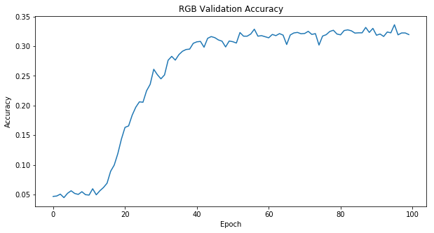

```python
from sklearn.utils import shuffle
import pickle


# Global settings to be used across each implementation
EPOCHS = 100
BATCH_SIZE = 128
LEARN_RATE = 0.001
DROP_PROB = 0.50

outputFrequency = 10



# Get the training data
training_file = 'data/train.p'
validation_file= 'data/valid.p'
#testing_file = 'data/test.p'

with open(training_file, mode='rb') as f:
    train = pickle.load(f)
with open(validation_file, mode='rb') as f:
    valid = pickle.load(f)
with open(testing_file, mode='rb') as f:
    test = pickle.load(f)

X_train, y_train = train['features'], train['labels']
X_valid, y_valid = valid['features'], valid['labels']
X_test, y_test = test['features'], test['labels']



# Get the images and labels
images = tf.placeholder(tf.float32,(None,32,32,3))
labels  = tf.placeholder(tf.int32,(None))
oneHotLabels = tf.one_hot(labels,43)
dropProb = tf.placeholder(tf.float32) # probability of keeping a node in

# Normalize the images - zero mean
X_train = np.array([np.array(normalizeRGB(img)) for img in X_train])
X_valid = np.array([np.array(normalizeRGB(img)) for img in X_valid])
X_test = np.array([np.array(normalizeRGB(img)) for img in X_test])



accuracies = list()

logits = myRGBNet(images,DROP_PROB)#vgg16(images)#leNet(images)
crossEntropy = tf.nn.softmax_cross_entropy_with_logits(labels=oneHotLabels, logits=logits)
lossOperation = tf.reduce_mean(crossEntropy)
optimizer = tf.train.AdamOptimizer(learning_rate=LEARN_RATE)
trainingOperation = optimizer.minimize(lossOperation)
correctPrediction = tf.equal(tf.argmax(logits, 1), tf.argmax(oneHotLabels, 1))
accuracyOperation = tf.reduce_mean(tf.cast(correctPrediction, tf.float32))
saver = tf.train.Saver()

# Run the network
with tf.Session() as sess:
    sess.run(tf.global_variables_initializer())
    num_examples = len(X_train)

    print("Training...")
    print()
    for i in range(EPOCHS):
        X_train, y_train = shuffle(X_train, y_train) # shuffle the training data to get a random selection per batch

        for offset in range(0, num_examples, BATCH_SIZE):
            end = offset + BATCH_SIZE
            batch_x, batch_y = X_train[offset:end], y_train[offset:end] # get BATCH_SIZE (i.e. 128) records to processes


            # Run the training on the batch
            sess.run(trainingOperation, feed_dict={images: batch_x, labels: batch_y, dropProb: DROP_PROB})

        # Validate the model
        validation_accuracy = evaluate(X_valid, y_valid, batchSize=BATCH_SIZE, channelCnt=3)
        accuracies.append(validation_accuracy)

        if (i)%outputFrequency == 0:
            print("EPOCH {} ... Validation Accuracy: {:.3f}".format(i, validation_accuracy))

    print("\nFINAL EPOCH {} ... Validation Accuracy: {:.3f}".format(i, validation_accuracy))

    saver.save(sess, './rgbNet_100_001_50.ckpt')
    print("Model saved")

    print("\nTesting Model")
    test_accuracy = sess.run(accuracyOperation, feed_dict={images: X_test, labels: y_test, dropProb: 1.0})
    print("TEST ACCURACY: {:.3f}".format(test_accuracy))

# Display chart of accuracy per epoch
vizAccuracies(accuracies,title='RGB Validation Accuracy')
```

#### 100 Epochs & 0.001 Learn Rate & 75% [not]Drop Probability (likely to be in the network)

```
Training...

EPOCH 0 ... Validation Accuracy: 0.055
EPOCH 10 ... Validation Accuracy: 0.639
EPOCH 20 ... Validation Accuracy: 0.813
EPOCH 30 ... Validation Accuracy: 0.859
EPOCH 40 ... Validation Accuracy: 0.878
EPOCH 50 ... Validation Accuracy: 0.899
EPOCH 60 ... Validation Accuracy: 0.907
EPOCH 70 ... Validation Accuracy: 0.894
EPOCH 80 ... Validation Accuracy: 0.905
EPOCH 90 ... Validation Accuracy: 0.916

FINAL EPOCH 99 ... Validation Accuracy: 0.903
Model saved

Testing Model
TEST ACCURACY: 0.900
```

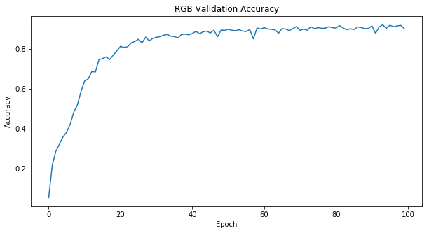

```python
from sklearn.utils import shuffle
import pickle


# Global settings to be used across each implementation
EPOCHS = 100
BATCH_SIZE = 128
LEARN_RATE = 0.001
DROP_PROB = 0.75

outputFrequency = 10



# Get the training data
training_file = 'data/train.p'
validation_file= 'data/valid.p'
testing_file = 'data/test.p'

with open(training_file, mode='rb') as f:
    train = pickle.load(f)
with open(validation_file, mode='rb') as f:
    valid = pickle.load(f)
with open(testing_file, mode='rb') as f:
    test = pickle.load(f)

X_train, y_train = train['features'], train['labels']
X_valid, y_valid = valid['features'], valid['labels']
X_test, y_test = test['features'], test['labels']



# Get the images and labels
images = tf.placeholder(tf.float32,(None,32,32,3))
labels  = tf.placeholder(tf.int32,(None))
oneHotLabels = tf.one_hot(labels,43)
dropProb = tf.placeholder(tf.float32) # probability of keeping a node in

# Normalize the images - zero mean
X_train = np.array([np.array(normalizeRGB(img)) for img in X_train])
X_valid = np.array([np.array(normalizeRGB(img)) for img in X_valid])
X_test = np.array([np.array(normalizeRGB(img)) for img in X_test])



accuracies = list()

logits = myRGBNet(images,DROP_PROB)#vgg16(images)#leNet(images)
crossEntropy = tf.nn.softmax_cross_entropy_with_logits(labels=oneHotLabels, logits=logits)
lossOperation = tf.reduce_mean(crossEntropy)
optimizer = tf.train.AdamOptimizer(learning_rate=LEARN_RATE)
trainingOperation = optimizer.minimize(lossOperation)
correctPrediction = tf.equal(tf.argmax(logits, 1), tf.argmax(oneHotLabels, 1))
accuracyOperation = tf.reduce_mean(tf.cast(correctPrediction, tf.float32))
saver = tf.train.Saver()

# Run the network
with tf.Session() as sess:
    sess.run(tf.global_variables_initializer())
    num_examples = len(X_train)

    print("Training...")
    print()
    for i in range(EPOCHS):
        X_train, y_train = shuffle(X_train, y_train) # shuffle the training data to get a random selection per batch

        for offset in range(0, num_examples, BATCH_SIZE):
            end = offset + BATCH_SIZE
            batch_x, batch_y = X_train[offset:end], y_train[offset:end] # get BATCH_SIZE (i.e. 128) records to processes


            # Run the training on the batch
            sess.run(trainingOperation, feed_dict={images: batch_x, labels: batch_y, dropProb: DROP_PROB})

        # Validate the model
        validation_accuracy = evaluate(X_valid, y_valid, batchSize=BATCH_SIZE, channelCnt=3)
        accuracies.append(validation_accuracy)

        if (i)%outputFrequency == 0:
            print("EPOCH {} ... Validation Accuracy: {:.3f}".format(i, validation_accuracy))

    print("\nFINAL EPOCH {} ... Validation Accuracy: {:.3f}".format(i, validation_accuracy))

    saver.save(sess, './rgbNet_100_001_75.ckpt')
    print("Model saved")

    print("\nTesting Model")
    test_accuracy = sess.run(accuracyOperation, feed_dict={images: X_test, labels: y_test, dropProb: 1.0})
    print("TEST ACCURACY: {:.3f}".format(test_accuracy))

# Display chart of accuracy per epoch
vizAccuracies(accuracies,title='RGB Validation Accuracy')
```

#### 1000 Epochs & 0.001 Learn Rate & 50% [not]Drop Probability (likely to be in the network)

[output not shown]

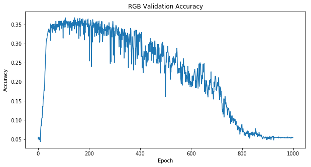

```python
from sklearn.utils import shuffle
import pickle


# Global settings to be used across each implementation
EPOCHS = 1000
BATCH_SIZE = 128
LEARN_RATE = 0.001
DROP_PROB = 0.50

outputFrequency = 100



# Get the training data
training_file = 'data/train.p'
validation_file= 'data/valid.p'
testing_file = 'data/test.p'

with open(training_file, mode='rb') as f:
    train = pickle.load(f)
with open(validation_file, mode='rb') as f:
    valid = pickle.load(f)
with open(testing_file, mode='rb') as f:
    test = pickle.load(f)

X_train, y_train = train['features'], train['labels']
X_valid, y_valid = valid['features'], valid['labels']
X_test, y_test = test['features'], test['labels']



# Get the images and labels
images = tf.placeholder(tf.float32,(None,32,32,3))
labels  = tf.placeholder(tf.int32,(None))
oneHotLabels = tf.one_hot(labels,43)
dropProb = tf.placeholder(tf.float32) # probability of keeping a node in

# Normalize the images - zero mean
X_train = np.array([np.array(normalizeRGB(img)) for img in X_train])
X_valid = np.array([np.array(normalizeRGB(img)) for img in X_valid])
X_test = np.array([np.array(normalizeRGB(img)) for img in X_test])



accuracies = list()

logits = myRGBNet(images,DROP_PROB)#vgg16(images)#leNet(images)
crossEntropy = tf.nn.softmax_cross_entropy_with_logits(labels=oneHotLabels, logits=logits)
lossOperation = tf.reduce_mean(crossEntropy)
optimizer = tf.train.AdamOptimizer(learning_rate=LEARN_RATE)
trainingOperation = optimizer.minimize(lossOperation)
correctPrediction = tf.equal(tf.argmax(logits, 1), tf.argmax(oneHotLabels, 1))
accuracyOperation = tf.reduce_mean(tf.cast(correctPrediction, tf.float32))
saver = tf.train.Saver()

# Run the network
with tf.Session() as sess:
    sess.run(tf.global_variables_initializer())
    num_examples = len(X_train)

    print("Training...")
    print()
    for i in range(EPOCHS):
        X_train, y_train = shuffle(X_train, y_train) # shuffle the training data to get a random selection per batch

        for offset in range(0, num_examples, BATCH_SIZE):
            end = offset + BATCH_SIZE
            batch_x, batch_y = X_train[offset:end], y_train[offset:end] # get BATCH_SIZE (i.e. 128) records to processes


            # Run the training on the batch
            sess.run(trainingOperation, feed_dict={images: batch_x, labels: batch_y, dropProb: DROP_PROB})

        # Validate the model
        validation_accuracy = evaluate(X_valid, y_valid, batchSize=BATCH_SIZE, channelCnt=3)
        accuracies.append(validation_accuracy)

        if (i)%outputFrequency == 0:
            print("EPOCH {} ... Validation Accuracy: {:.3f}".format(i, validation_accuracy))

    print("\nFINAL EPOCH {} ... Validation Accuracy: {:.3f}".format(i, validation_accuracy))

    saver.save(sess, './rgbNet_1000_001_50.ckpt')
    print("Model saved")

    print("\nTesting Model")
    test_accuracy = sess.run(accuracyOperation, feed_dict={images: X_test, labels: y_test, dropProb: 1.0})
    print("TEST ACCURACY: {:.3f}".format(test_accuracy))

# Display chart of accuracy per epoch
vizAccuracies(accuracies,title='RGB Validation Accuracy')
```

### Try Greyscale

#### 10 Epochs & 0.001 Learn Rate & 100% [not]Drop Probability (likely to be in the network)

```
Training...

EPOCH 0 ... Validation Accuracy: 0.821
EPOCH 1 ... Validation Accuracy: 0.881
EPOCH 2 ... Validation Accuracy: 0.916
EPOCH 3 ... Validation Accuracy: 0.919
EPOCH 4 ... Validation Accuracy: 0.921
EPOCH 5 ... Validation Accuracy: 0.941
EPOCH 6 ... Validation Accuracy: 0.914
EPOCH 7 ... Validation Accuracy: 0.926
EPOCH 8 ... Validation Accuracy: 0.922
EPOCH 9 ... Validation Accuracy: 0.955

FINAL EPOCH 9 ... Validation Accuracy: 0.955
Model saved

Testing Model
TEST ACCURACY: 0.917
```

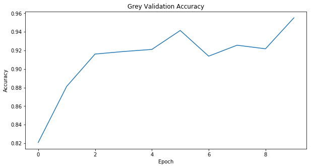

```python
from sklearn.utils import shuffle
import pickle


# Global settings to be used across each implementation
EPOCHS = 10
BATCH_SIZE = 128
LEARN_RATE = 0.001
DROP_PROB = 1.0

outputFrequency = 1



# Get the training data
training_file = 'data/train.p'
validation_file= 'data/valid.p'
#testing_file = 'data/test.p'

with open(training_file, mode='rb') as f:
    train = pickle.load(f)
with open(validation_file, mode='rb') as f:
    valid = pickle.load(f)
with open(testing_file, mode='rb') as f:
    test = pickle.load(f)

X_train, y_train = train['features'], train['labels']
X_valid, y_valid = valid['features'], valid['labels']
X_test, y_test = test['features'], test['labels']



# Get the images and labels
images = tf.placeholder(tf.float32,(None,32,32,1))
labels  = tf.placeholder(tf.int32,(None))
oneHotLabels = tf.one_hot(labels,43)
dropProb = tf.placeholder(tf.float32) # probability of keeping a node in

# convert to greyscale
X_train = np.array([rgb2Grey(img, weights=[.299,.587,.114]) for img in X_train])
X_valid = np.array([rgb2Grey(img, weights=[.299,.587,.114]) for img in X_valid])
X_test = np.array([rgb2Grey(img, weights=[.299,.587,.114]) for img in X_test])

# Normalize the images - zero mean
X_train = np.array([np.array(normalizeGrey(img)) for img in X_train])
X_valid = np.array([np.array(normalizeGrey(img)) for img in X_valid])
X_test = np.array([np.array(normalizeGrey(img)) for img in X_test])




accuracies = list()

logits = myGreyNet(images,DROP_PROB)#vgg16(images)#leNet(images)
crossEntropy = tf.nn.softmax_cross_entropy_with_logits(labels=oneHotLabels, logits=logits)
lossOperation = tf.reduce_mean(crossEntropy)
optimizer = tf.train.AdamOptimizer(learning_rate=LEARN_RATE)
trainingOperation = optimizer.minimize(lossOperation)
correctPrediction = tf.equal(tf.argmax(logits, 1), tf.argmax(oneHotLabels, 1))
accuracyOperation = tf.reduce_mean(tf.cast(correctPrediction, tf.float32))
saver = tf.train.Saver()

# Run the network
with tf.Session() as sess:
    sess.run(tf.global_variables_initializer())
    num_examples = len(X_train)

    print("Training...")
    print()
    for i in range(EPOCHS):
        X_train, y_train = shuffle(X_train, y_train) # shuffle the training data to get a random selection per batch

        for offset in range(0, num_examples, BATCH_SIZE):
            end = offset + BATCH_SIZE
            batch_x, batch_y = X_train[offset:end], y_train[offset:end] # get BATCH_SIZE (i.e. 128) records to processes
            batch_x = batch_x.reshape((batch_x.shape[0],32,32,1))

            # Run the training on the batch
            sess.run(trainingOperation, feed_dict={images: batch_x, labels: batch_y, dropProb: DROP_PROB})

        # Validate the model
        validation_accuracy = evaluate(X_valid, y_valid, batchSize=BATCH_SIZE, channelCnt=1)
        accuracies.append(validation_accuracy)

        if (i)%outputFrequency == 0:
            print("EPOCH {} ... Validation Accuracy: {:.3f}".format(i, validation_accuracy))

    print("\nFINAL EPOCH {} ... Validation Accuracy: {:.3f}".format(i, validation_accuracy))

    saver.save(sess, './greyNet_10_001_100.ckpt')
    print("Model saved")

    print("\nTesting Model")
    X_test = X_test.reshape((X_test.shape[0],32,32,1))
    test_accuracy = sess.run(accuracyOperation, feed_dict={images: X_test, labels: y_test, dropProb: 1.0})
    print("TEST ACCURACY: {:.3f}".format(test_accuracy))

# Display chart of accuracy per epoch
vizAccuracies(accuracies,title='Grey Validation Accuracy')
```

#### 10 Epochs & 0.001 Learn Rate & 50% [not]Drop Probability (likely to be in the network)

```
Training...

EPOCH 0 ... Validation Accuracy: 0.051
EPOCH 1 ... Validation Accuracy: 0.046
EPOCH 2 ... Validation Accuracy: 0.054
EPOCH 3 ... Validation Accuracy: 0.053
EPOCH 4 ... Validation Accuracy: 0.057
EPOCH 5 ... Validation Accuracy: 0.065
EPOCH 6 ... Validation Accuracy: 0.066
EPOCH 7 ... Validation Accuracy: 0.072
EPOCH 8 ... Validation Accuracy: 0.071
EPOCH 9 ... Validation Accuracy: 0.068

FINAL EPOCH 9 ... Validation Accuracy: 0.068
Model saved

Testing Model
TEST ACCURACY: 0.082
```

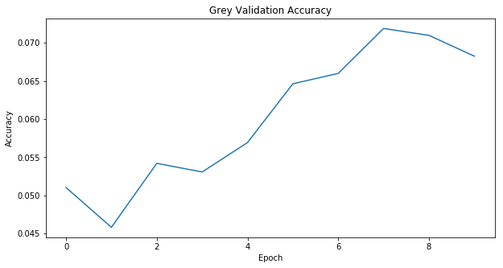

```python
from sklearn.utils import shuffle
import pickle


# Global settings to be used across each implementation
EPOCHS = 10
BATCH_SIZE = 128
LEARN_RATE = 0.001
DROP_PROB = 0.50

outputFrequency = 1



# Get the training data
training_file = 'data/train.p'
validation_file= 'data/valid.p'
testing_file = 'data/test.p'

with open(training_file, mode='rb') as f:
    train = pickle.load(f)
with open(validation_file, mode='rb') as f:
    valid = pickle.load(f)
with open(testing_file, mode='rb') as f:
    test = pickle.load(f)

X_train, y_train = train['features'], train['labels']
X_valid, y_valid = valid['features'], valid['labels']
X_test, y_test = test['features'], test['labels']



# Get the images and labels
images = tf.placeholder(tf.float32,(None,32,32,1))
labels  = tf.placeholder(tf.int32,(None))
oneHotLabels = tf.one_hot(labels,43)
dropProb = tf.placeholder(tf.float32) # probability of keeping a node in

# convert to greyscale
X_train = np.array([rgb2Grey(img, weights=[.299,.587,.114]) for img in X_train])
X_valid = np.array([rgb2Grey(img, weights=[.299,.587,.114]) for img in X_valid])
X_test = np.array([rgb2Grey(img, weights=[.299,.587,.114]) for img in X_test])

# Normalize the images - zero mean
X_train = np.array([np.array(normalizeGrey(img)) for img in X_train])
X_valid = np.array([np.array(normalizeGrey(img)) for img in X_valid])
X_test = np.array([np.array(normalizeGrey(img)) for img in X_test])




accuracies = list()

logits = myGreyNet(images,DROP_PROB)#vgg16(images)#leNet(images)
crossEntropy = tf.nn.softmax_cross_entropy_with_logits(labels=oneHotLabels, logits=logits)
lossOperation = tf.reduce_mean(crossEntropy)
optimizer = tf.train.AdamOptimizer(learning_rate=LEARN_RATE)
trainingOperation = optimizer.minimize(lossOperation)
correctPrediction = tf.equal(tf.argmax(logits, 1), tf.argmax(oneHotLabels, 1))
accuracyOperation = tf.reduce_mean(tf.cast(correctPrediction, tf.float32))
saver = tf.train.Saver()

# Run the network
with tf.Session() as sess:
    sess.run(tf.global_variables_initializer())
    num_examples = len(X_train)

    print("Training...")
    print()
    for i in range(EPOCHS):
        X_train, y_train = shuffle(X_train, y_train) # shuffle the training data to get a random selection per batch

        for offset in range(0, num_examples, BATCH_SIZE):
            end = offset + BATCH_SIZE
            batch_x, batch_y = X_train[offset:end], y_train[offset:end] # get BATCH_SIZE (i.e. 128) records to processes
            batch_x = batch_x.reshape((batch_x.shape[0],32,32,1))

            # Run the training on the batch
            sess.run(trainingOperation, feed_dict={images: batch_x, labels: batch_y, dropProb: DROP_PROB})

        # Validate the model
        validation_accuracy = evaluate(X_valid, y_valid, batchSize=BATCH_SIZE, channelCnt=1)
        accuracies.append(validation_accuracy)

        if (i)%outputFrequency == 0:
            print("EPOCH {} ... Validation Accuracy: {:.3f}".format(i, validation_accuracy))

    print("\nFINAL EPOCH {} ... Validation Accuracy: {:.3f}".format(i, validation_accuracy))

    saver.save(sess, './greyNet_10_001_50.ckpt')
    print("Model saved")

    print("\nTesting Model")
    X_test = X_test.reshape((X_test.shape[0],32,32,1))
    test_accuracy = sess.run(accuracyOperation, feed_dict={images: X_test, labels: y_test, dropProb: 1.0})
    print("TEST ACCURACY: {:.3f}".format(test_accuracy))

# Display chart of accuracy per epoch
vizAccuracies(accuracies,title='Grey Validation Accuracy')
```

#### 10 Epochs & 0.001 Learn Rate & 75% [not]Drop Probability (likely to be in the network)

```
Training...

EPOCH 0 ... Validation Accuracy: 0.052
EPOCH 1 ... Validation Accuracy: 0.087
EPOCH 2 ... Validation Accuracy: 0.197
EPOCH 3 ... Validation Accuracy: 0.333
EPOCH 4 ... Validation Accuracy: 0.446
EPOCH 5 ... Validation Accuracy: 0.527
EPOCH 6 ... Validation Accuracy: 0.621
EPOCH 7 ... Validation Accuracy: 0.670
EPOCH 8 ... Validation Accuracy: 0.707
EPOCH 9 ... Validation Accuracy: 0.737

FINAL EPOCH 9 ... Validation Accuracy: 0.737
Model saved

Testing Model
TEST ACCURACY: 0.746
```

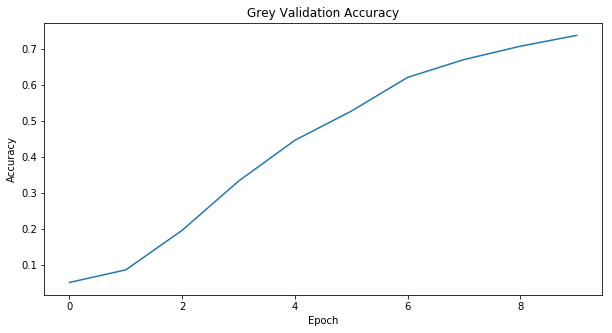

```python
from sklearn.utils import shuffle
import pickle


# Global settings to be used across each implementation
EPOCHS = 10
BATCH_SIZE = 128
LEARN_RATE = 0.001
DROP_PROB = 0.75

outputFrequency = 1



# Get the training data
training_file = 'data/train.p'
validation_file= 'data/valid.p'
testing_file = 'data/test.p'

with open(training_file, mode='rb') as f:
    train = pickle.load(f)
with open(validation_file, mode='rb') as f:
    valid = pickle.load(f)
with open(testing_file, mode='rb') as f:
    test = pickle.load(f)

X_train, y_train = train['features'], train['labels']
X_valid, y_valid = valid['features'], valid['labels']
X_test, y_test = test['features'], test['labels']



# Get the images and labels
images = tf.placeholder(tf.float32,(None,32,32,1))
labels  = tf.placeholder(tf.int32,(None))
oneHotLabels = tf.one_hot(labels,43)
dropProb = tf.placeholder(tf.float32) # probability of keeping a node in

# convert to greyscale
X_train = np.array([rgb2Grey(img, weights=[.299,.587,.114]) for img in X_train])
X_valid = np.array([rgb2Grey(img, weights=[.299,.587,.114]) for img in X_valid])
X_test = np.array([rgb2Grey(img, weights=[.299,.587,.114]) for img in X_test])

# Normalize the images - zero mean
X_train = np.array([np.array(normalizeGrey(img)) for img in X_train])
X_valid = np.array([np.array(normalizeGrey(img)) for img in X_valid])
X_test = np.array([np.array(normalizeGrey(img)) for img in X_test])




accuracies = list()

logits = myGreyNet(images,DROP_PROB)#vgg16(images)#leNet(images)
crossEntropy = tf.nn.softmax_cross_entropy_with_logits(labels=oneHotLabels, logits=logits)
lossOperation = tf.reduce_mean(crossEntropy)
optimizer = tf.train.AdamOptimizer(learning_rate=LEARN_RATE)
trainingOperation = optimizer.minimize(lossOperation)
correctPrediction = tf.equal(tf.argmax(logits, 1), tf.argmax(oneHotLabels, 1))
accuracyOperation = tf.reduce_mean(tf.cast(correctPrediction, tf.float32))
saver = tf.train.Saver()

# Run the network
with tf.Session() as sess:
    sess.run(tf.global_variables_initializer())
    num_examples = len(X_train)

    print("Training...")
    print()
    for i in range(EPOCHS):
        X_train, y_train = shuffle(X_train, y_train) # shuffle the training data to get a random selection per batch

        for offset in range(0, num_examples, BATCH_SIZE):
            end = offset + BATCH_SIZE
            batch_x, batch_y = X_train[offset:end], y_train[offset:end] # get BATCH_SIZE (i.e. 128) records to processes
            batch_x = batch_x.reshape((batch_x.shape[0],32,32,1))

            # Run the training on the batch
            sess.run(trainingOperation, feed_dict={images: batch_x, labels: batch_y, dropProb: DROP_PROB})

        # Validate the model
        validation_accuracy = evaluate(X_valid, y_valid, batchSize=BATCH_SIZE, channelCnt=1)
        accuracies.append(validation_accuracy)

        if (i)%outputFrequency == 0:
            print("EPOCH {} ... Validation Accuracy: {:.3f}".format(i, validation_accuracy))

    print("\nFINAL EPOCH {} ... Validation Accuracy: {:.3f}".format(i, validation_accuracy))

    saver.save(sess, './greyNet_10_001_75.ckpt')
    print("Model saved")

    print("\nTesting Model")
    X_test = X_test.reshape((X_test.shape[0],32,32,1))
    test_accuracy = sess.run(accuracyOperation, feed_dict={images: X_test, labels: y_test, dropProb: 1.0})
    print("TEST ACCURACY: {:.3f}".format(test_accuracy))

# Display chart of accuracy per epoch
vizAccuracies(accuracies,title='Grey Validation Accuracy')
```

#### 100 Epochs & 0.001 Learn Rate & 100% [not]Drop Probability (likely to be in the network)

```
Training...

EPOCH 0 ... Validation Accuracy: 0.755
EPOCH 10 ... Validation Accuracy: 0.939
EPOCH 20 ... Validation Accuracy: 0.931
EPOCH 30 ... Validation Accuracy: 0.939
EPOCH 40 ... Validation Accuracy: 0.960
EPOCH 50 ... Validation Accuracy: 0.958
EPOCH 60 ... Validation Accuracy: 0.968
EPOCH 70 ... Validation Accuracy: 0.957
EPOCH 80 ... Validation Accuracy: 0.954
EPOCH 90 ... Validation Accuracy: 0.974

FINAL EPOCH 99 ... Validation Accuracy: 0.966
Model saved

Testing Model
TEST ACCURACY: 0.949
```

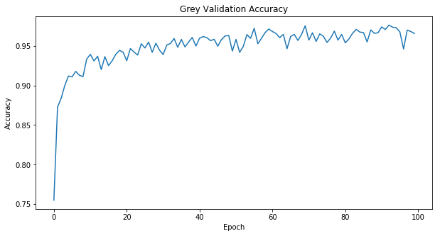

```python
from sklearn.utils import shuffle
import pickle


# Global settings to be used across each implementation
EPOCHS = 100
BATCH_SIZE = 128
LEARN_RATE = 0.001
DROP_PROB = 1.0

outputFrequency = 10



# Get the training data
training_file = 'data/train.p'
validation_file= 'data/valid.p'
testing_file = 'data/test.p'

with open(training_file, mode='rb') as f:
    train = pickle.load(f)
with open(validation_file, mode='rb') as f:
    valid = pickle.load(f)
with open(testing_file, mode='rb') as f:
    test = pickle.load(f)

X_train, y_train = train['features'], train['labels']
X_valid, y_valid = valid['features'], valid['labels']
X_test, y_test = test['features'], test['labels']



# Get the images and labels
images = tf.placeholder(tf.float32,(None,32,32,1))
labels  = tf.placeholder(tf.int32,(None))
oneHotLabels = tf.one_hot(labels,43)
dropProb = tf.placeholder(tf.float32) # probability of keeping a node in

# convert to greyscale
X_train = np.array([rgb2Grey(img, weights=[.299,.587,.114]) for img in X_train])
X_valid = np.array([rgb2Grey(img, weights=[.299,.587,.114]) for img in X_valid])
X_test = np.array([rgb2Grey(img, weights=[.299,.587,.114]) for img in X_test])

# Normalize the images - zero mean
X_train = np.array([np.array(normalizeGrey(img)) for img in X_train])
X_valid = np.array([np.array(normalizeGrey(img)) for img in X_valid])
X_test = np.array([np.array(normalizeGrey(img)) for img in X_test])




accuracies = list()

logits = myGreyNet(images,DROP_PROB)#vgg16(images)#leNet(images)
crossEntropy = tf.nn.softmax_cross_entropy_with_logits(labels=oneHotLabels, logits=logits)
lossOperation = tf.reduce_mean(crossEntropy)
optimizer = tf.train.AdamOptimizer(learning_rate=LEARN_RATE)
trainingOperation = optimizer.minimize(lossOperation)
correctPrediction = tf.equal(tf.argmax(logits, 1), tf.argmax(oneHotLabels, 1))
accuracyOperation = tf.reduce_mean(tf.cast(correctPrediction, tf.float32))
saver = tf.train.Saver()

# Run the network
with tf.Session() as sess:
    sess.run(tf.global_variables_initializer())
    num_examples = len(X_train)

    print("Training...")
    print()
    for i in range(EPOCHS):
        X_train, y_train = shuffle(X_train, y_train) # shuffle the training data to get a random selection per batch

        for offset in range(0, num_examples, BATCH_SIZE):
            end = offset + BATCH_SIZE
            batch_x, batch_y = X_train[offset:end], y_train[offset:end] # get BATCH_SIZE (i.e. 128) records to processes
            batch_x = batch_x.reshape((batch_x.shape[0],32,32,1))

            # Run the training on the batch
            sess.run(trainingOperation, feed_dict={images: batch_x, labels: batch_y, dropProb: DROP_PROB})

        # Validate the model
        validation_accuracy = evaluate(X_valid, y_valid, batchSize=BATCH_SIZE, channelCnt=1)
        accuracies.append(validation_accuracy)

        if (i)%outputFrequency == 0:
            print("EPOCH {} ... Validation Accuracy: {:.3f}".format(i, validation_accuracy))

    print("\nFINAL EPOCH {} ... Validation Accuracy: {:.3f}".format(i, validation_accuracy))

    saver.save(sess, './greyNet_100_001_100.ckpt')
    print("Model saved")

    print("\nTesting Model")
    X_test = X_test.reshape((X_test.shape[0],32,32,1))
    test_accuracy = sess.run(accuracyOperation, feed_dict={images: X_test, labels: y_test, dropProb: 1.0})
    print("TEST ACCURACY: {:.3f}".format(test_accuracy))

# Display chart of accuracy per epoch
vizAccuracies(accuracies,title='Grey Validation Accuracy')
```

#### 100 Epochs & 0.001 Learn Rate & 50% [not]Drop Probability (likely to be in the network)

```
Training...

EPOCH 0 ... Validation Accuracy: 0.047
EPOCH 10 ... Validation Accuracy: 0.070
EPOCH 20 ... Validation Accuracy: 0.204
EPOCH 30 ... Validation Accuracy: 0.290
EPOCH 40 ... Validation Accuracy: 0.334
EPOCH 50 ... Validation Accuracy: 0.384
EPOCH 60 ... Validation Accuracy: 0.420
EPOCH 70 ... Validation Accuracy: 0.451
EPOCH 80 ... Validation Accuracy: 0.390
EPOCH 90 ... Validation Accuracy: 0.481

FINAL EPOCH 99 ... Validation Accuracy: 0.477
Model saved

Testing Model
TEST ACCURACY: 0.501
```

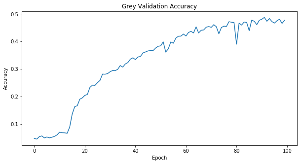

```python
from sklearn.utils import shuffle
import pickle


# Global settings to be used across each implementation
EPOCHS = 100
BATCH_SIZE = 128
LEARN_RATE = 0.001
DROP_PROB = 0.50

outputFrequency = 10



# Get the training data
training_file = 'data/train.p'
validation_file= 'data/valid.p'
testing_file = 'data/test.p'

with open(training_file, mode='rb') as f:
    train = pickle.load(f)
with open(validation_file, mode='rb') as f:
    valid = pickle.load(f)
with open(testing_file, mode='rb') as f:
    test = pickle.load(f)

X_train, y_train = train['features'], train['labels']
X_valid, y_valid = valid['features'], valid['labels']
X_test, y_test = test['features'], test['labels']



# Get the images and labels
images = tf.placeholder(tf.float32,(None,32,32,1))
labels  = tf.placeholder(tf.int32,(None))
oneHotLabels = tf.one_hot(labels,43)
dropProb = tf.placeholder(tf.float32) # probability of keeping a node in

# convert to greyscale
X_train = np.array([rgb2Grey(img, weights=[.299,.587,.114]) for img in X_train])
X_valid = np.array([rgb2Grey(img, weights=[.299,.587,.114]) for img in X_valid])
X_test = np.array([rgb2Grey(img, weights=[.299,.587,.114]) for img in X_test])

# Normalize the images - zero mean
X_train = np.array([np.array(normalizeGrey(img)) for img in X_train])
X_valid = np.array([np.array(normalizeGrey(img)) for img in X_valid])
X_test = np.array([np.array(normalizeGrey(img)) for img in X_test])




accuracies = list()

logits = myGreyNet(images,DROP_PROB)#vgg16(images)#leNet(images)
crossEntropy = tf.nn.softmax_cross_entropy_with_logits(labels=oneHotLabels, logits=logits)
lossOperation = tf.reduce_mean(crossEntropy)
optimizer = tf.train.AdamOptimizer(learning_rate=LEARN_RATE)
trainingOperation = optimizer.minimize(lossOperation)
correctPrediction = tf.equal(tf.argmax(logits, 1), tf.argmax(oneHotLabels, 1))
accuracyOperation = tf.reduce_mean(tf.cast(correctPrediction, tf.float32))
saver = tf.train.Saver()

# Run the network
with tf.Session() as sess:
    sess.run(tf.global_variables_initializer())
    num_examples = len(X_train)

    print("Training...")
    print()
    for i in range(EPOCHS):
        X_train, y_train = shuffle(X_train, y_train) # shuffle the training data to get a random selection per batch

        for offset in range(0, num_examples, BATCH_SIZE):
            end = offset + BATCH_SIZE
            batch_x, batch_y = X_train[offset:end], y_train[offset:end] # get BATCH_SIZE (i.e. 128) records to processes
            batch_x = batch_x.reshape((batch_x.shape[0],32,32,1))

            # Run the training on the batch
            sess.run(trainingOperation, feed_dict={images: batch_x, labels: batch_y, dropProb: DROP_PROB})

        # Validate the model
        validation_accuracy = evaluate(X_valid, y_valid, batchSize=BATCH_SIZE, channelCnt=1)
        accuracies.append(validation_accuracy)

        if (i)%outputFrequency == 0:
            print("EPOCH {} ... Validation Accuracy: {:.3f}".format(i, validation_accuracy))

    print("\nFINAL EPOCH {} ... Validation Accuracy: {:.3f}".format(i, validation_accuracy))

    saver.save(sess, './greyNet_100_001_50.ckpt')
    print("Model saved")

    print("\nTesting Model")
    X_test = X_test.reshape((X_test.shape[0],32,32,1))
    test_accuracy = sess.run(accuracyOperation, feed_dict={images: X_test, labels: y_test, dropProb: 1.0})
    print("TEST ACCURACY: {:.3f}".format(test_accuracy))

# Display chart of accuracy per epoch
vizAccuracies(accuracies,title='Grey Validation Accuracy')
```

#### 100 Epochs & 0.001 Learn Rate & 75% [not]Drop Probability (likely to be in the network)

```
Training...

EPOCH 0 ... Validation Accuracy: 0.052
EPOCH 10 ... Validation Accuracy: 0.798
EPOCH 20 ... Validation Accuracy: 0.892
EPOCH 30 ... Validation Accuracy: 0.907
EPOCH 40 ... Validation Accuracy: 0.917
EPOCH 50 ... Validation Accuracy: 0.930
EPOCH 60 ... Validation Accuracy: 0.917
EPOCH 70 ... Validation Accuracy: 0.929
EPOCH 80 ... Validation Accuracy: 0.927
EPOCH 90 ... Validation Accuracy: 0.927

FINAL EPOCH 99 ... Validation Accuracy: 0.923
Model saved

Testing Model
TEST ACCURACY: 0.906
```

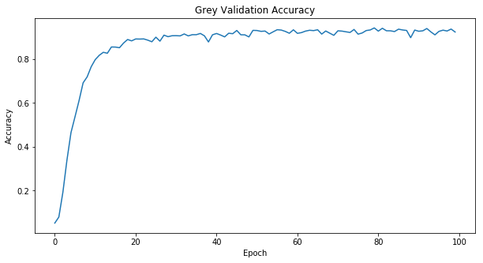

```python
from sklearn.utils import shuffle
import pickle


# Global settings to be used across each implementation
EPOCHS = 100
BATCH_SIZE = 128
LEARN_RATE = 0.001
DROP_PROB = 0.75

outputFrequency = 10



# Get the training data
training_file = 'data/train.p'
validation_file= 'data/valid.p'
#testing_file = 'data/test.p'

with open(training_file, mode='rb') as f:
    train = pickle.load(f)
with open(validation_file, mode='rb') as f:
    valid = pickle.load(f)
with open(testing_file, mode='rb') as f:
    test = pickle.load(f)

X_train, y_train = train['features'], train['labels']
X_valid, y_valid = valid['features'], valid['labels']
X_test, y_test = test['features'], test['labels']



# Get the images and labels
images = tf.placeholder(tf.float32,(None,32,32,1))
labels  = tf.placeholder(tf.int32,(None))
oneHotLabels = tf.one_hot(labels,43)
dropProb = tf.placeholder(tf.float32) # probability of keeping a node in

# convert to greyscale
X_train = np.array([rgb2Grey(img, weights=[.299,.587,.114]) for img in X_train])
X_valid = np.array([rgb2Grey(img, weights=[.299,.587,.114]) for img in X_valid])
X_test = np.array([rgb2Grey(img, weights=[.299,.587,.114]) for img in X_test])

# Normalize the images - zero mean
X_train = np.array([np.array(normalizeGrey(img)) for img in X_train])
X_valid = np.array([np.array(normalizeGrey(img)) for img in X_valid])
X_test = np.array([np.array(normalizeGrey(img)) for img in X_test])




accuracies = list()

logits = myGreyNet(images,DROP_PROB)#vgg16(images)#leNet(images)
crossEntropy = tf.nn.softmax_cross_entropy_with_logits(labels=oneHotLabels, logits=logits)
lossOperation = tf.reduce_mean(crossEntropy)
optimizer = tf.train.AdamOptimizer(learning_rate=LEARN_RATE)
trainingOperation = optimizer.minimize(lossOperation)
correctPrediction = tf.equal(tf.argmax(logits, 1), tf.argmax(oneHotLabels, 1))
accuracyOperation = tf.reduce_mean(tf.cast(correctPrediction, tf.float32))
saver = tf.train.Saver()

# Run the network
with tf.Session() as sess:
    sess.run(tf.global_variables_initializer())
    num_examples = len(X_train)

    print("Training...")
    print()
    for i in range(EPOCHS):
        X_train, y_train = shuffle(X_train, y_train) # shuffle the training data to get a random selection per batch

        for offset in range(0, num_examples, BATCH_SIZE):
            end = offset + BATCH_SIZE
            batch_x, batch_y = X_train[offset:end], y_train[offset:end] # get BATCH_SIZE (i.e. 128) records to processes
            batch_x = batch_x.reshape((batch_x.shape[0],32,32,1))

            # Run the training on the batch
            sess.run(trainingOperation, feed_dict={images: batch_x, labels: batch_y, dropProb: DROP_PROB})

        # Validate the model
        validation_accuracy = evaluate(X_valid, y_valid, batchSize=BATCH_SIZE, channelCnt=1)
        accuracies.append(validation_accuracy)

        if (i)%outputFrequency == 0:
            print("EPOCH {} ... Validation Accuracy: {:.3f}".format(i, validation_accuracy))

    print("\nFINAL EPOCH {} ... Validation Accuracy: {:.3f}".format(i, validation_accuracy))

    saver.save(sess, './greyNet_100_001_75.ckpt')
    print("Model saved")

    print("\nTesting Model")
    X_test = X_test.reshape((X_test.shape[0],32,32,1))
    test_accuracy = sess.run(accuracyOperation, feed_dict={images: X_test, labels: y_test, dropProb: 1.0})
    print("TEST ACCURACY: {:.3f}".format(test_accuracy))

# Display chart of accuracy per epoch
vizAccuracies(accuracies,title='Grey Validation Accuracy')
```

#### 1000 Epochs & 0.001 Learn Rate & 50% [not]Drop Probability (likely to be in the network)

```
Training...

EPOCH 0 ... Validation Accuracy: 0.049
EPOCH 100 ... Validation Accuracy: 0.526
EPOCH 200 ... Validation Accuracy: 0.479
EPOCH 300 ... Validation Accuracy: 0.485
EPOCH 400 ... Validation Accuracy: 0.420
EPOCH 500 ... Validation Accuracy: 0.371
EPOCH 600 ... Validation Accuracy: 0.243
EPOCH 700 ... Validation Accuracy: 0.206
EPOCH 800 ... Validation Accuracy: 0.125
EPOCH 900 ... Validation Accuracy: 0.088

FINAL EPOCH 999 ... Validation Accuracy: 0.056
Model saved
```

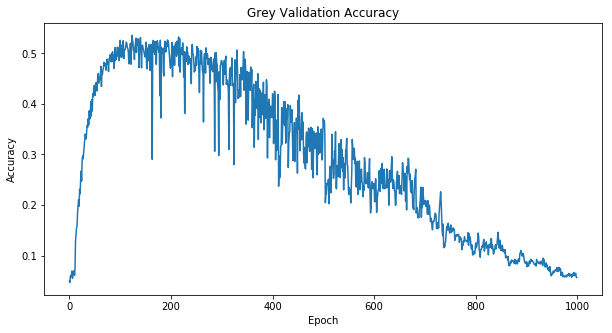

```python
from sklearn.utils import shuffle
import pickle


# Global settings to be used across each implementation
EPOCHS = 1000
BATCH_SIZE = 128
LEARN_RATE = 0.001
DROP_PROB = 0.50

outputFrequency = 100



# Get the training data
training_file = 'data/train.p'
validation_file= 'data/valid.p'
testing_file = 'data/test.p'

with open(training_file, mode='rb') as f:
    train = pickle.load(f)
with open(validation_file, mode='rb') as f:
    valid = pickle.load(f)
with open(testing_file, mode='rb') as f:
    test = pickle.load(f)

X_train, y_train = train['features'], train['labels']
X_valid, y_valid = valid['features'], valid['labels']
X_test, y_test = test['features'], test['labels']



# Get the images and labels
images = tf.placeholder(tf.float32,(None,32,32,1))
labels  = tf.placeholder(tf.int32,(None))
oneHotLabels = tf.one_hot(labels,43)
dropProb = tf.placeholder(tf.float32) # probability of keeping a node in

# convert to greyscale
X_train = np.array([rgb2Grey(img, weights=[.299,.587,.114]) for img in X_train])
X_valid = np.array([rgb2Grey(img, weights=[.299,.587,.114]) for img in X_valid])
X_test = np.array([rgb2Grey(img, weights=[.299,.587,.114]) for img in X_test])

# Normalize the images - zero mean
X_train = np.array([np.array(normalizeGrey(img)) for img in X_train])
X_valid = np.array([np.array(normalizeGrey(img)) for img in X_valid])
X_test = np.array([np.array(normalizeGrey(img)) for img in X_test])




accuracies = list()

logits = myGreyNet(images,DROP_PROB)#vgg16(images)#leNet(images)
crossEntropy = tf.nn.softmax_cross_entropy_with_logits(labels=oneHotLabels, logits=logits)
lossOperation = tf.reduce_mean(crossEntropy)
optimizer = tf.train.AdamOptimizer(learning_rate=LEARN_RATE)
trainingOperation = optimizer.minimize(lossOperation)
correctPrediction = tf.equal(tf.argmax(logits, 1), tf.argmax(oneHotLabels, 1))
accuracyOperation = tf.reduce_mean(tf.cast(correctPrediction, tf.float32))
saver = tf.train.Saver()

# Run the network
with tf.Session() as sess:
    sess.run(tf.global_variables_initializer())
    num_examples = len(X_train)

    print("Training...")
    print()
    for i in range(EPOCHS):
        X_train, y_train = shuffle(X_train, y_train) # shuffle the training data to get a random selection per batch

        for offset in range(0, num_examples, BATCH_SIZE):
            end = offset + BATCH_SIZE
            batch_x, batch_y = X_train[offset:end], y_train[offset:end] # get BATCH_SIZE (i.e. 128) records to processes
            batch_x = batch_x.reshape((batch_x.shape[0],32,32,1))

            # Run the training on the batch
            sess.run(trainingOperation, feed_dict={images: batch_x, labels: batch_y, dropProb: DROP_PROB})

        # Validate the model
        validation_accuracy = evaluate(X_valid, y_valid, batchSize=BATCH_SIZE, channelCnt=1)
        accuracies.append(validation_accuracy)

        if (i)%outputFrequency == 0:
            print("EPOCH {} ... Validation Accuracy: {:.3f}".format(i, validation_accuracy))

    print("\nFINAL EPOCH {} ... Validation Accuracy: {:.3f}".format(i, validation_accuracy))

    saver.save(sess, './greyNet_1000_001_50.ckpt')
    print("Model saved")

    print("\nTesting Model")
    X_test = X_test.reshape((X_test.shape[0],32,32,1))
    test_accuracy = sess.run(accuracyOperation, feed_dict={images: X_test, labels: y_test, dropProb: 1.0})
    print("TEST ACCURACY: {:.3f}".format(test_accuracy))

# Display chart of accuracy per epoch
vizAccuracies(accuracies,title='Grey Validation Accuracy')
```

### Try RGB + Greyscale

```
Training...

EPOCH 0 ... Validation Accuracy: 0.037
EPOCH 1 ... Validation Accuracy: 0.034
EPOCH 2 ... Validation Accuracy: 0.036
EPOCH 3 ... Validation Accuracy: 0.041
EPOCH 4 ... Validation Accuracy: 0.044
EPOCH 5 ... Validation Accuracy: 0.044
EPOCH 6 ... Validation Accuracy: 0.043
EPOCH 7 ... Validation Accuracy: 0.043
EPOCH 8 ... Validation Accuracy: 0.045
EPOCH 9 ... Validation Accuracy: 0.043

FINAL EPOCH 9 ... Validation Accuracy: 0.043
Model saved

Testing Model
TEST ACCURACY: 0.052
```

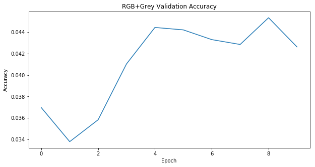

```python
from sklearn.utils import shuffle
import pickle


# Global settings to be used across each implementation
EPOCHS = 10
BATCH_SIZE = 128
LEARN_RATE = 0.001
DROP_PROB = 0.100

outputFrequency = 1



# Get the training data
training_file = 'data/train.p'
validation_file= 'data/valid.p'
testing_file = 'data/test.p'

with open(training_file, mode='rb') as f:
    train = pickle.load(f)
with open(validation_file, mode='rb') as f:
    valid = pickle.load(f)
with open(testing_file, mode='rb') as f:
    test = pickle.load(f)

X_train, y_train = train['features'], train['labels']
X_valid, y_valid = valid['features'], valid['labels']
X_test, y_test = test['features'], test['labels']



# Get the images and labels
images = tf.placeholder(tf.float32,(None,32,32,4))
labels  = tf.placeholder(tf.int32,(None))
oneHotLabels = tf.one_hot(labels,43)
dropProb = tf.placeholder(tf.float32) # probability of keeping a node in

# convert to rgb + greyscale - 4 channels (r,g,b,grey)
X_train = np.array([np.concatenate((img,np.array(rgb2Grey(img, weights=[.299,.587,.114])).reshape(32,32,1)),2) for img in X_train])
X_valid = np.array([np.concatenate((img,np.array(rgb2Grey(img, weights=[.299,.587,.114])).reshape(32,32,1)),2) for img in X_valid])
X_test = np.array([np.concatenate((img,np.array(rgb2Grey(img, weights=[.299,.587,.114])).reshape(32,32,1)),2) for img in X_test])

# Normalize the images - zero mean
X_train = np.array([np.array(normalizeRGBGrey(img)) for img in X_train])
X_valid = np.array([np.array(normalizeRGBGrey(img)) for img in X_valid])
X_test = np.array([np.array(normalizeRGBGrey(img)) for img in X_test])



accuracies = list()

logits = myRGBGreyNet(images,DROP_PROB)#vgg16(images)#leNet(images)
crossEntropy = tf.nn.softmax_cross_entropy_with_logits(labels=oneHotLabels, logits=logits)
lossOperation = tf.reduce_mean(crossEntropy)
optimizer = tf.train.AdamOptimizer(learning_rate=LEARN_RATE)
trainingOperation = optimizer.minimize(lossOperation)
correctPrediction = tf.equal(tf.argmax(logits, 1), tf.argmax(oneHotLabels, 1))
accuracyOperation = tf.reduce_mean(tf.cast(correctPrediction, tf.float32))
saver = tf.train.Saver()

# Run the network
with tf.Session() as sess:
    sess.run(tf.global_variables_initializer())
    num_examples = len(X_train)

    print("Training...")
    print()
    for i in range(EPOCHS):
        X_train, y_train = shuffle(X_train, y_train) # shuffle the training data to get a random selection per batch

        for offset in range(0, num_examples, BATCH_SIZE):
            end = offset + BATCH_SIZE
            batch_x, batch_y = X_train[offset:end], y_train[offset:end] # get BATCH_SIZE (i.e. 128) records to processes
            batch_x = batch_x.reshape((batch_x.shape[0],32,32,4))

            # Run the training on the batch
            sess.run(trainingOperation, feed_dict={images: batch_x, labels: batch_y, dropProb: DROP_PROB})

        # Validate the model
        validation_accuracy = evaluate(X_valid, y_valid, batchSize=BATCH_SIZE, channelCnt=4)
        accuracies.append(validation_accuracy)

        if (i)%outputFrequency == 0:
            print("EPOCH {} ... Validation Accuracy: {:.3f}".format(i, validation_accuracy))

    print("\nFINAL EPOCH {} ... Validation Accuracy: {:.3f}".format(i, validation_accuracy))

    saver.save(sess, './rgbGreyNet_10_001_100.ckpt')
    print("Model saved")

    print("\nTesting Model")
    X_test = X_test.reshape((X_test.shape[0],32,32,4))
    test_accuracy = sess.run(accuracyOperation, feed_dict={images: X_test, labels: y_test, dropProb: 1.0})
    print("TEST ACCURACY: {:.3f}".format(test_accuracy))

# Display chart of accuracy per epoch
vizAccuracies(accuracies,title='RGB+Grey Validation Accuracy')
```

#### 10 Epochs & 0.001 Learn Rate & 50% [not]Drop Probability (likely to be in the network)

```
Training...

EPOCH 0 ... Validation Accuracy: 0.047
EPOCH 1 ... Validation Accuracy: 0.055
EPOCH 2 ... Validation Accuracy: 0.046
EPOCH 3 ... Validation Accuracy: 0.051
EPOCH 4 ... Validation Accuracy: 0.056
EPOCH 5 ... Validation Accuracy: 0.058
EPOCH 6 ... Validation Accuracy: 0.059
EPOCH 7 ... Validation Accuracy: 0.064
EPOCH 8 ... Validation Accuracy: 0.060
EPOCH 9 ... Validation Accuracy: 0.064

FINAL EPOCH 9 ... Validation Accuracy: 0.064
Model saved

Testing Model
TEST ACCURACY: 0.075
```

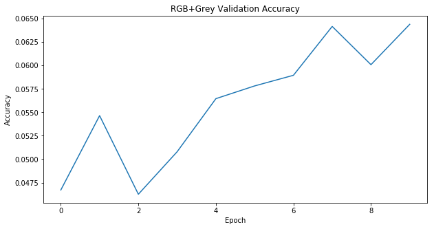

```python
from sklearn.utils import shuffle
import pickle


# Global settings to be used across each implementation
EPOCHS = 10
BATCH_SIZE = 128
LEARN_RATE = 0.001
DROP_PROB = 0.50

outputFrequency = 1



# Get the training data
training_file = 'data/train.p'
validation_file= 'data/valid.p'
testing_file = 'data/test.p'

with open(training_file, mode='rb') as f:
    train = pickle.load(f)
with open(validation_file, mode='rb') as f:
    valid = pickle.load(f)
with open(testing_file, mode='rb') as f:
    test = pickle.load(f)

X_train, y_train = train['features'], train['labels']
X_valid, y_valid = valid['features'], valid['labels']
X_test, y_test = test['features'], test['labels']



# Get the images and labels
images = tf.placeholder(tf.float32,(None,32,32,4))
labels  = tf.placeholder(tf.int32,(None))
oneHotLabels = tf.one_hot(labels,43)
dropProb = tf.placeholder(tf.float32) # probability of keeping a node in

# convert to rgb + greyscale - 4 channels (r,g,b,grey)
X_train = np.array([np.concatenate((img,np.array(rgb2Grey(img, weights=[.299,.587,.114])).reshape(32,32,1)),2) for img in X_train])
X_valid = np.array([np.concatenate((img,np.array(rgb2Grey(img, weights=[.299,.587,.114])).reshape(32,32,1)),2) for img in X_valid])
X_test = np.array([np.concatenate((img,np.array(rgb2Grey(img, weights=[.299,.587,.114])).reshape(32,32,1)),2) for img in X_test])

# Normalize the images - zero mean
X_train = np.array([np.array(normalizeRGBGrey(img)) for img in X_train])
X_valid = np.array([np.array(normalizeRGBGrey(img)) for img in X_valid])
X_test = np.array([np.array(normalizeRGBGrey(img)) for img in X_test])



accuracies = list()

logits = myRGBGreyNet(images,DROP_PROB)#vgg16(images)#leNet(images)
crossEntropy = tf.nn.softmax_cross_entropy_with_logits(labels=oneHotLabels, logits=logits)
lossOperation = tf.reduce_mean(crossEntropy)
optimizer = tf.train.AdamOptimizer(learning_rate=LEARN_RATE)
trainingOperation = optimizer.minimize(lossOperation)
correctPrediction = tf.equal(tf.argmax(logits, 1), tf.argmax(oneHotLabels, 1))
accuracyOperation = tf.reduce_mean(tf.cast(correctPrediction, tf.float32))
saver = tf.train.Saver()

# Run the network
with tf.Session() as sess:
    sess.run(tf.global_variables_initializer())
    num_examples = len(X_train)

    print("Training...")
    print()
    for i in range(EPOCHS):
        X_train, y_train = shuffle(X_train, y_train) # shuffle the training data to get a random selection per batch

        for offset in range(0, num_examples, BATCH_SIZE):
            end = offset + BATCH_SIZE
            batch_x, batch_y = X_train[offset:end], y_train[offset:end] # get BATCH_SIZE (i.e. 128) records to processes
            batch_x = batch_x.reshape((batch_x.shape[0],32,32,4))

            # Run the training on the batch
            sess.run(trainingOperation, feed_dict={images: batch_x, labels: batch_y, dropProb: DROP_PROB})

        # Validate the model
        validation_accuracy = evaluate(X_valid, y_valid, batchSize=BATCH_SIZE, channelCnt=4)
        accuracies.append(validation_accuracy)

        if (i)%outputFrequency == 0:
            print("EPOCH {} ... Validation Accuracy: {:.3f}".format(i, validation_accuracy))

    print("\nFINAL EPOCH {} ... Validation Accuracy: {:.3f}".format(i, validation_accuracy))

    saver.save(sess, './rgbGreyNet_10_001_50.ckpt')
    print("Model saved")

    print("\nTesting Model")
    X_test = X_test.reshape((X_test.shape[0],32,32,4))
    test_accuracy = sess.run(accuracyOperation, feed_dict={images: X_test, labels: y_test, dropProb: 1.0})
    print("TEST ACCURACY: {:.3f}".format(test_accuracy))

# Display chart of accuracy per epoch
vizAccuracies(accuracies,title='RGB+Grey Validation Accuracy')
```

#### 10 Epochs & 0.001 Learn Rate & 75% [not]Drop Probability (likely to be in the network)

```
Training...

EPOCH 0 ... Validation Accuracy: 0.053
EPOCH 1 ... Validation Accuracy: 0.063
EPOCH 2 ... Validation Accuracy: 0.227
EPOCH 3 ... Validation Accuracy: 0.289
EPOCH 4 ... Validation Accuracy: 0.374
EPOCH 5 ... Validation Accuracy: 0.406
EPOCH 6 ... Validation Accuracy: 0.459
EPOCH 7 ... Validation Accuracy: 0.524
EPOCH 8 ... Validation Accuracy: 0.559
EPOCH 9 ... Validation Accuracy: 0.614

FINAL EPOCH 9 ... Validation Accuracy: 0.614
Model saved

Testing Model
TEST ACCURACY: 0.618
```

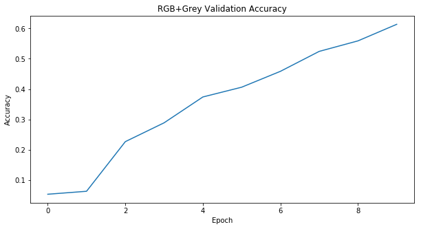

```python
from sklearn.utils import shuffle
import pickle


# Global settings to be used across each implementation
EPOCHS = 10
BATCH_SIZE = 128
LEARN_RATE = 0.001
DROP_PROB = 0.75

outputFrequency = 1



# Get the training data
training_file = 'data/train.p'
validation_file= 'data/valid.p'
testing_file = 'data/test.p'

with open(training_file, mode='rb') as f:
    train = pickle.load(f)
with open(validation_file, mode='rb') as f:
    valid = pickle.load(f)
with open(testing_file, mode='rb') as f:
    test = pickle.load(f)

X_train, y_train = train['features'], train['labels']
X_valid, y_valid = valid['features'], valid['labels']
X_test, y_test = test['features'], test['labels']



# Get the images and labels
images = tf.placeholder(tf.float32,(None,32,32,4))
labels  = tf.placeholder(tf.int32,(None))
oneHotLabels = tf.one_hot(labels,43)
dropProb = tf.placeholder(tf.float32) # probability of keeping a node in

# convert to rgb + greyscale - 4 channels (r,g,b,grey)
X_train = np.array([np.concatenate((img,np.array(rgb2Grey(img, weights=[.299,.587,.114])).reshape(32,32,1)),2) for img in X_train])
X_valid = np.array([np.concatenate((img,np.array(rgb2Grey(img, weights=[.299,.587,.114])).reshape(32,32,1)),2) for img in X_valid])
X_test = np.array([np.concatenate((img,np.array(rgb2Grey(img, weights=[.299,.587,.114])).reshape(32,32,1)),2) for img in X_test])

# Normalize the images - zero mean
X_train = np.array([np.array(normalizeRGBGrey(img)) for img in X_train])
X_valid = np.array([np.array(normalizeRGBGrey(img)) for img in X_valid])
X_test = np.array([np.array(normalizeRGBGrey(img)) for img in X_test])



accuracies = list()

logits = myRGBGreyNet(images,DROP_PROB)#vgg16(images)#leNet(images)
crossEntropy = tf.nn.softmax_cross_entropy_with_logits(labels=oneHotLabels, logits=logits)
lossOperation = tf.reduce_mean(crossEntropy)
optimizer = tf.train.AdamOptimizer(learning_rate=LEARN_RATE)
trainingOperation = optimizer.minimize(lossOperation)
correctPrediction = tf.equal(tf.argmax(logits, 1), tf.argmax(oneHotLabels, 1))
accuracyOperation = tf.reduce_mean(tf.cast(correctPrediction, tf.float32))
saver = tf.train.Saver()

# Run the network
with tf.Session() as sess:
    sess.run(tf.global_variables_initializer())
    num_examples = len(X_train)

    print("Training...")
    print()
    for i in range(EPOCHS):
        X_train, y_train = shuffle(X_train, y_train) # shuffle the training data to get a random selection per batch

        for offset in range(0, num_examples, BATCH_SIZE):
            end = offset + BATCH_SIZE
            batch_x, batch_y = X_train[offset:end], y_train[offset:end] # get BATCH_SIZE (i.e. 128) records to processes
            batch_x = batch_x.reshape((batch_x.shape[0],32,32,4))

            # Run the training on the batch
            sess.run(trainingOperation, feed_dict={images: batch_x, labels: batch_y, dropProb: DROP_PROB})

        # Validate the model
        validation_accuracy = evaluate(X_valid, y_valid, batchSize=BATCH_SIZE, channelCnt=4)
        accuracies.append(validation_accuracy)

        if (i)%outputFrequency == 0:
            print("EPOCH {} ... Validation Accuracy: {:.3f}".format(i, validation_accuracy))

    print("\nFINAL EPOCH {} ... Validation Accuracy: {:.3f}".format(i, validation_accuracy))

    saver.save(sess, './rgbGreyNet_10_001_75.ckpt')
    print("Model saved")

    print("\nTesting Model")
    X_test = X_test.reshape((X_test.shape[0],32,32,4))
    test_accuracy = sess.run(accuracyOperation, feed_dict={images: X_test, labels: y_test, dropProb: 1.0})
    print("TEST ACCURACY: {:.3f}".format(test_accuracy))

# Display chart of accuracy per epoch
vizAccuracies(accuracies,title='RGB+Grey Validation Accuracy')
```

```
Training...

EPOCH 0 ... Validation Accuracy: 0.030
EPOCH 10 ... Validation Accuracy: 0.046
EPOCH 20 ... Validation Accuracy: 0.049
EPOCH 30 ... Validation Accuracy: 0.054
EPOCH 40 ... Validation Accuracy: 0.054
EPOCH 50 ... Validation Accuracy: 0.054
EPOCH 60 ... Validation Accuracy: 0.054
EPOCH 70 ... Validation Accuracy: 0.054
EPOCH 80 ... Validation Accuracy: 0.054
EPOCH 90 ... Validation Accuracy: 0.054

FINAL EPOCH 99 ... Validation Accuracy: 0.054
Model saved

Testing Model
TEST ACCURACY: 0.059
```

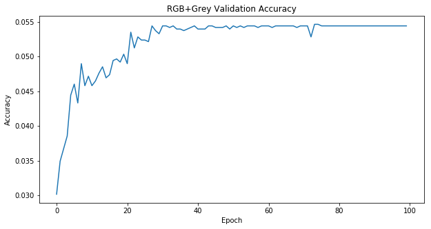

```python
from sklearn.utils import shuffle
import pickle


# Global settings to be used across each implementation
EPOCHS = 100
BATCH_SIZE = 128
LEARN_RATE = 0.001
DROP_PROB = 0.100

outputFrequency = 10



# Get the training data
training_file = 'data/train.p'
validation_file= 'data/valid.p'
testing_file = 'data/test.p'

with open(training_file, mode='rb') as f:
    train = pickle.load(f)
with open(validation_file, mode='rb') as f:
    valid = pickle.load(f)
with open(testing_file, mode='rb') as f:
    test = pickle.load(f)

X_train, y_train = train['features'], train['labels']
X_valid, y_valid = valid['features'], valid['labels']
X_test, y_test = test['features'], test['labels']



# Get the images and labels
images = tf.placeholder(tf.float32,(None,32,32,4))
labels  = tf.placeholder(tf.int32,(None))
oneHotLabels = tf.one_hot(labels,43)
dropProb = tf.placeholder(tf.float32) # probability of keeping a node in

# convert to rgb + greyscale - 4 channels (r,g,b,grey)
X_train = np.array([np.concatenate((img,np.array(rgb2Grey(img, weights=[.299,.587,.114])).reshape(32,32,1)),2) for img in X_train])
X_valid = np.array([np.concatenate((img,np.array(rgb2Grey(img, weights=[.299,.587,.114])).reshape(32,32,1)),2) for img in X_valid])
X_test = np.array([np.concatenate((img,np.array(rgb2Grey(img, weights=[.299,.587,.114])).reshape(32,32,1)),2) for img in X_test])

# Normalize the images - zero mean
X_train = np.array([np.array(normalizeRGBGrey(img)) for img in X_train])
X_valid = np.array([np.array(normalizeRGBGrey(img)) for img in X_valid])
X_test = np.array([np.array(normalizeRGBGrey(img)) for img in X_test])



accuracies = list()

logits = myRGBGreyNet(images,DROP_PROB)#vgg16(images)#leNet(images)
crossEntropy = tf.nn.softmax_cross_entropy_with_logits(labels=oneHotLabels, logits=logits)
lossOperation = tf.reduce_mean(crossEntropy)
optimizer = tf.train.AdamOptimizer(learning_rate=LEARN_RATE)
trainingOperation = optimizer.minimize(lossOperation)
correctPrediction = tf.equal(tf.argmax(logits, 1), tf.argmax(oneHotLabels, 1))
accuracyOperation = tf.reduce_mean(tf.cast(correctPrediction, tf.float32))
saver = tf.train.Saver()

# Run the network
with tf.Session() as sess:
    sess.run(tf.global_variables_initializer())
    num_examples = len(X_train)

    print("Training...")
    print()
    for i in range(EPOCHS):
        X_train, y_train = shuffle(X_train, y_train) # shuffle the training data to get a random selection per batch

        for offset in range(0, num_examples, BATCH_SIZE):
            end = offset + BATCH_SIZE
            batch_x, batch_y = X_train[offset:end], y_train[offset:end] # get BATCH_SIZE (i.e. 128) records to processes
            batch_x = batch_x.reshape((batch_x.shape[0],32,32,4))

            # Run the training on the batch
            sess.run(trainingOperation, feed_dict={images: batch_x, labels: batch_y, dropProb: DROP_PROB})

        # Validate the model
        validation_accuracy = evaluate(X_valid, y_valid, batchSize=BATCH_SIZE, channelCnt=4)
        accuracies.append(validation_accuracy)

        if (i)%outputFrequency == 0:
            print("EPOCH {} ... Validation Accuracy: {:.3f}".format(i, validation_accuracy))

    print("\nFINAL EPOCH {} ... Validation Accuracy: {:.3f}".format(i, validation_accuracy))

    saver.save(sess, './rgbGreyNet_100_001_100.ckpt')
    print("Model saved")

    print("\nTesting Model")
    X_test = X_test.reshape((X_test.shape[0],32,32,4))
    test_accuracy = sess.run(accuracyOperation, feed_dict={images: X_test, labels: y_test, dropProb: 1.0})
    print("TEST ACCURACY: {:.3f}".format(test_accuracy))

# Display chart of accuracy per epoch
vizAccuracies(accuracies,title='RGB+Grey Validation Accuracy')
```

#### 100 Epochs & 0.001 Learn Rate & 50% [not]Drop Probability (likely to be in the network)

```
Training...

EPOCH 0 ... Validation Accuracy: 0.040
EPOCH 10 ... Validation Accuracy: 0.100
EPOCH 20 ... Validation Accuracy: 0.129
EPOCH 30 ... Validation Accuracy: 0.277
EPOCH 40 ... Validation Accuracy: 0.312
EPOCH 50 ... Validation Accuracy: 0.346
EPOCH 60 ... Validation Accuracy: 0.352
EPOCH 70 ... Validation Accuracy: 0.355
EPOCH 80 ... Validation Accuracy: 0.371
EPOCH 90 ... Validation Accuracy: 0.370

FINAL EPOCH 99 ... Validation Accuracy: 0.379
Model saved

Testing Model
TEST ACCURACY: 0.380
```

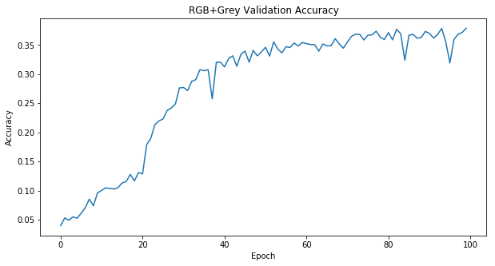

```python
from sklearn.utils import shuffle
import pickle


# Global settings to be used across each implementation
EPOCHS = 100
BATCH_SIZE = 128
LEARN_RATE = 0.001
DROP_PROB = 0.50

outputFrequency = 10



# Get the training data
training_file = 'data/train.p'
validation_file= 'data/valid.p'
testing_file = 'data/test.p'

with open(training_file, mode='rb') as f:
    train = pickle.load(f)
with open(validation_file, mode='rb') as f:
    valid = pickle.load(f)
with open(testing_file, mode='rb') as f:
    test = pickle.load(f)

X_train, y_train = train['features'], train['labels']
X_valid, y_valid = valid['features'], valid['labels']
X_test, y_test = test['features'], test['labels']



# Get the images and labels
images = tf.placeholder(tf.float32,(None,32,32,4))
labels  = tf.placeholder(tf.int32,(None))
oneHotLabels = tf.one_hot(labels,43)
dropProb = tf.placeholder(tf.float32) # probability of keeping a node in

# convert to rgb + greyscale - 4 channels (r,g,b,grey)
X_train = np.array([np.concatenate((img,np.array(rgb2Grey(img, weights=[.299,.587,.114])).reshape(32,32,1)),2) for img in X_train])
X_valid = np.array([np.concatenate((img,np.array(rgb2Grey(img, weights=[.299,.587,.114])).reshape(32,32,1)),2) for img in X_valid])
X_test = np.array([np.concatenate((img,np.array(rgb2Grey(img, weights=[.299,.587,.114])).reshape(32,32,1)),2) for img in X_test])

# Normalize the images - zero mean
X_train = np.array([np.array(normalizeRGBGrey(img)) for img in X_train])
X_valid = np.array([np.array(normalizeRGBGrey(img)) for img in X_valid])
X_test = np.array([np.array(normalizeRGBGrey(img)) for img in X_test])



accuracies = list()

logits = myRGBGreyNet(images,DROP_PROB)#vgg16(images)#leNet(images)
crossEntropy = tf.nn.softmax_cross_entropy_with_logits(labels=oneHotLabels, logits=logits)
lossOperation = tf.reduce_mean(crossEntropy)
optimizer = tf.train.AdamOptimizer(learning_rate=LEARN_RATE)
trainingOperation = optimizer.minimize(lossOperation)
correctPrediction = tf.equal(tf.argmax(logits, 1), tf.argmax(oneHotLabels, 1))
accuracyOperation = tf.reduce_mean(tf.cast(correctPrediction, tf.float32))
saver = tf.train.Saver()

# Run the network
with tf.Session() as sess:
    sess.run(tf.global_variables_initializer())
    num_examples = len(X_train)

    print("Training...")
    print()
    for i in range(EPOCHS):
        X_train, y_train = shuffle(X_train, y_train) # shuffle the training data to get a random selection per batch

        for offset in range(0, num_examples, BATCH_SIZE):
            end = offset + BATCH_SIZE
            batch_x, batch_y = X_train[offset:end], y_train[offset:end] # get BATCH_SIZE (i.e. 128) records to processes
            batch_x = batch_x.reshape((batch_x.shape[0],32,32,4))

            # Run the training on the batch
            sess.run(trainingOperation, feed_dict={images: batch_x, labels: batch_y, dropProb: DROP_PROB})

        # Validate the model
        validation_accuracy = evaluate(X_valid, y_valid, batchSize=BATCH_SIZE, channelCnt=4)
        accuracies.append(validation_accuracy)

        if (i)%outputFrequency == 0:
            print("EPOCH {} ... Validation Accuracy: {:.3f}".format(i, validation_accuracy))

    print("\nFINAL EPOCH {} ... Validation Accuracy: {:.3f}".format(i, validation_accuracy))

    saver.save(sess, './rgbGreyNet_100_001_50.ckpt')
    print("Model saved")

    print("\nTesting Model")
    X_test = X_test.reshape((X_test.shape[0],32,32,4))
    test_accuracy = sess.run(accuracyOperation, feed_dict={images: X_test, labels: y_test, dropProb: 1.0})
    print("TEST ACCURACY: {:.3f}".format(test_accuracy))

# Display chart of accuracy per epoch
vizAccuracies(accuracies,title='RGB+Grey Validation Accuracy')
```

#### 100 Epochs & 0.001 Learn Rate & 75% [not]Drop Probability (likely to be in the network)

```
Training...

EPOCH 0 ... Validation Accuracy: 0.053
EPOCH 10 ... Validation Accuracy: 0.740
EPOCH 20 ... Validation Accuracy: 0.830
EPOCH 30 ... Validation Accuracy: 0.842
EPOCH 40 ... Validation Accuracy: 0.891
EPOCH 50 ... Validation Accuracy: 0.897
EPOCH 60 ... Validation Accuracy: 0.911
EPOCH 70 ... Validation Accuracy: 0.892
EPOCH 80 ... Validation Accuracy: 0.904
EPOCH 90 ... Validation Accuracy: 0.905

FINAL EPOCH 99 ... Validation Accuracy: 0.915
Model saved

Testing Model
TEST ACCURACY: 0.906
```

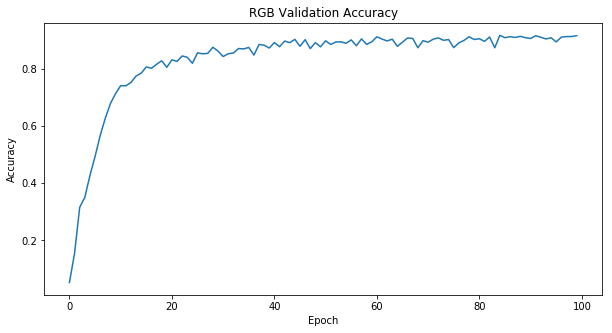

```python
from sklearn.utils import shuffle
import pickle


# Global settings to be used across each implementation
EPOCHS = 100
BATCH_SIZE = 128
LEARN_RATE = 0.001
DROP_PROB = 0.75

outputFrequency = 10



# Get the training data
training_file = 'data/train.p'
validation_file= 'data/valid.p'
testing_file = 'data/test.p'

with open(training_file, mode='rb') as f:
    train = pickle.load(f)
with open(validation_file, mode='rb') as f:
    valid = pickle.load(f)
with open(testing_file, mode='rb') as f:
    test = pickle.load(f)

X_train, y_train = train['features'], train['labels']
X_valid, y_valid = valid['features'], valid['labels']
X_test, y_test = test['features'], test['labels']



# Get the images and labels
images = tf.placeholder(tf.float32,(None,32,32,4))
labels  = tf.placeholder(tf.int32,(None))
oneHotLabels = tf.one_hot(labels,43)
dropProb = tf.placeholder(tf.float32) # probability of keeping a node in

# convert to rgb + greyscale - 4 channels (r,g,b,grey)
X_train = np.array([np.concatenate((img,np.array(rgb2Grey(img, weights=[.299,.587,.114])).reshape(32,32,1)),2) for img in X_train])
X_valid = np.array([np.concatenate((img,np.array(rgb2Grey(img, weights=[.299,.587,.114])).reshape(32,32,1)),2) for img in X_valid])
X_test = np.array([np.concatenate((img,np.array(rgb2Grey(img, weights=[.299,.587,.114])).reshape(32,32,1)),2) for img in X_test])

# Normalize the images - zero mean
X_train = np.array([np.array(normalizeRGBGrey(img)) for img in X_train])
X_valid = np.array([np.array(normalizeRGBGrey(img)) for img in X_valid])
X_test = np.array([np.array(normalizeRGBGrey(img)) for img in X_test])



accuracies = list()

logits = myRGBGreyNet(images,DROP_PROB)#vgg16(images)#leNet(images)
crossEntropy = tf.nn.softmax_cross_entropy_with_logits(labels=oneHotLabels, logits=logits)
lossOperation = tf.reduce_mean(crossEntropy)
optimizer = tf.train.AdamOptimizer(learning_rate=LEARN_RATE)
trainingOperation = optimizer.minimize(lossOperation)
correctPrediction = tf.equal(tf.argmax(logits, 1), tf.argmax(oneHotLabels, 1))
accuracyOperation = tf.reduce_mean(tf.cast(correctPrediction, tf.float32))
saver = tf.train.Saver()

# Run the network
with tf.Session() as sess:
    sess.run(tf.global_variables_initializer())
    num_examples = len(X_train)

    print("Training...")
    print()
    for i in range(EPOCHS):
        X_train, y_train = shuffle(X_train, y_train) # shuffle the training data to get a random selection per batch

        for offset in range(0, num_examples, BATCH_SIZE):
            end = offset + BATCH_SIZE
            batch_x, batch_y = X_train[offset:end], y_train[offset:end] # get BATCH_SIZE (i.e. 128) records to processes
            batch_x = batch_x.reshape((batch_x.shape[0],32,32,4))

            # Run the training on the batch
            sess.run(trainingOperation, feed_dict={images: batch_x, labels: batch_y, dropProb: DROP_PROB})

        # Validate the model
        validation_accuracy = evaluate(X_valid, y_valid, batchSize=BATCH_SIZE, channelCnt=4)
        accuracies.append(validation_accuracy)

        if (i)%outputFrequency == 0:
            print("EPOCH {} ... Validation Accuracy: {:.3f}".format(i, validation_accuracy))

    print("\nFINAL EPOCH {} ... Validation Accuracy: {:.3f}".format(i, validation_accuracy))

    saver.save(sess, './rgbGreyNet_100_001_75.ckpt')
    print("Model saved")

    print("\nTesting Model")
    X_test = X_test.reshape((X_test.shape[0],32,32,4))
    test_accuracy = sess.run(accuracyOperation, feed_dict={images: X_test, labels: y_test, dropProb: 1.0})
    print("TEST ACCURACY: {:.3f}".format(test_accuracy))

# Display chart of accuracy per epoch
vizAccuracies(accuracies,title='RGB Validation Accuracy')
```

#### 1000 Epochs & 0.001 Learn Rate & 50% [not]Drop Probability (likely to be in the network)

```
Training...

EPOCH 0 ... Validation Accuracy: 0.051
EPOCH 100 ... Validation Accuracy: 0.260
EPOCH 200 ... Validation Accuracy: 0.344
EPOCH 300 ... Validation Accuracy: 0.331
EPOCH 400 ... Validation Accuracy: 0.253
EPOCH 500 ... Validation Accuracy: 0.277
EPOCH 600 ... Validation Accuracy: 0.229
EPOCH 700 ... Validation Accuracy: 0.058
EPOCH 800 ... Validation Accuracy: 0.058
EPOCH 900 ... Validation Accuracy: 0.055

FINAL EPOCH 999 ... Validation Accuracy: 0.054
Model saved
```

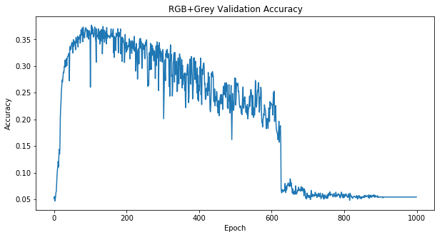

```python
from sklearn.utils import shuffle
import pickle


# Global settings to be used across each implementation
EPOCHS = 1000
BATCH_SIZE = 128
LEARN_RATE = 0.001
DROP_PROB = 0.50

outputFrequency = 100



# Get the training data
training_file = 'data/train.p'
validation_file= 'data/valid.p'
testing_file = 'data/test.p'

with open(training_file, mode='rb') as f:
    train = pickle.load(f)
with open(validation_file, mode='rb') as f:
    valid = pickle.load(f)
with open(testing_file, mode='rb') as f:
    test = pickle.load(f)

X_train, y_train = train['features'], train['labels']
X_valid, y_valid = valid['features'], valid['labels']
X_test, y_test = test['features'], test['labels']



# Get the images and labels
images = tf.placeholder(tf.float32,(None,32,32,4))
labels  = tf.placeholder(tf.int32,(None))
oneHotLabels = tf.one_hot(labels,43)
dropProb = tf.placeholder(tf.float32) # probability of keeping a node in

# convert to rgb + greyscale - 4 channels (r,g,b,grey)
X_train = np.array([np.concatenate((img,np.array(rgb2Grey(img, weights=[.299,.587,.114])).reshape(32,32,1)),2) for img in X_train])
X_valid = np.array([np.concatenate((img,np.array(rgb2Grey(img, weights=[.299,.587,.114])).reshape(32,32,1)),2) for img in X_valid])
X_test = np.array([np.concatenate((img,np.array(rgb2Grey(img, weights=[.299,.587,.114])).reshape(32,32,1)),2) for img in X_test])

# Normalize the images - zero mean
X_train = np.array([np.array(normalizeRGBGrey(img)) for img in X_train])
X_valid = np.array([np.array(normalizeRGBGrey(img)) for img in X_valid])
X_test = np.array([np.array(normalizeRGBGrey(img)) for img in X_test])



accuracies = list()

logits = myRGBGreyNet(images,DROP_PROB)#vgg16(images)#leNet(images)
crossEntropy = tf.nn.softmax_cross_entropy_with_logits(labels=oneHotLabels, logits=logits)
lossOperation = tf.reduce_mean(crossEntropy)
optimizer = tf.train.AdamOptimizer(learning_rate=LEARN_RATE)
trainingOperation = optimizer.minimize(lossOperation)
correctPrediction = tf.equal(tf.argmax(logits, 1), tf.argmax(oneHotLabels, 1))
accuracyOperation = tf.reduce_mean(tf.cast(correctPrediction, tf.float32))
saver = tf.train.Saver()

# Run the network
with tf.Session() as sess:
    sess.run(tf.global_variables_initializer())
    num_examples = len(X_train)

    print("Training...")
    print()
    for i in range(EPOCHS):
        X_train, y_train = shuffle(X_train, y_train) # shuffle the training data to get a random selection per batch

        for offset in range(0, num_examples, BATCH_SIZE):
            end = offset + BATCH_SIZE
            batch_x, batch_y = X_train[offset:end], y_train[offset:end] # get BATCH_SIZE (i.e. 128) records to processes
            batch_x = batch_x.reshape((batch_x.shape[0],32,32,4))

            # Run the training on the batch
            sess.run(trainingOperation, feed_dict={images: batch_x, labels: batch_y, dropProb: DROP_PROB})

        # Validate the model
        validation_accuracy = evaluate(X_valid, y_valid, batchSize=BATCH_SIZE, channelCnt=4)
        accuracies.append(validation_accuracy)

        if (i)%outputFrequency == 0:
            print("EPOCH {} ... Validation Accuracy: {:.3f}".format(i, validation_accuracy))

    print("\nFINAL EPOCH {} ... Validation Accuracy: {:.3f}".format(i, validation_accuracy))

    saver.save(sess, './rgbGreyNet_1000_001_50.ckpt')
    print("Model saved")

    print("\nTesting Model")
    X_test = X_test.reshape((X_test.shape[0],32,32,4))
    test_accuracy = sess.run(accuracyOperation, feed_dict={images: X_test, labels: y_test, dropProb: 1.0})
    print("TEST ACCURACY: {:.3f}".format(test_accuracy))

# Display chart of accuracy per epoch
vizAccuracies(accuracies,title='RGB+Grey Validation Accuracy')
```

## Step 3: Test a Model on New Images

To give yourself more insight into how your model is working, download at least five pictures of German traffic signs from the web and use your model to predict the traffic sign type.

You may find `signnames.csv` useful as it contains mappings from the class id (integer) to the actual sign name.

### Load and Output the Images

```python
### Load the images and plot them here.
### Feel free to use as many code cells as needed.
```

```python
import pandas as pd

dfSigns = pd.read_csv('./signnames.csv')
dfSigns
```

|  | ClassId | SignName |
| --- | --- | --- |
| 0 | 0 | Speed limit (20km/h) |
| 1 | 1 | Speed limit (30km/h) |
| 2 | 2 | Speed limit (50km/h) |
| 3 | 3 | Speed limit (60km/h) |
| 4 | 4 | Speed limit (70km/h) |
| 5 | 5 | Speed limit (80km/h) |
| 6 | 6 | End of speed limit (80km/h) |
| 7 | 7 | Speed limit (100km/h) |
| 8 | 8 | Speed limit (120km/h) |
| 9 | 9 | No passing |
| 10 | 10 | No passing for vehicles over 3.5 metric tons |
| 11 | 11 | Right-of-way at the next intersection |
| 12 | 12 | Priority road |
| 13 | 13 | Yield |
| 14 | 14 | Stop |
| 15 | 15 | No vehicles |
| 16 | 16 | Vehicles over 3.5 metric tons prohibited |
| 17 | 17 | No entry |
| 18 | 18 | General caution |
| 19 | 19 | Dangerous curve to the left |
| 20 | 20 | Dangerous curve to the right |
| 21 | 21 | Double curve |
| 22 | 22 | Bumpy road |
| 23 | 23 | Slippery road |
| 24 | 24 | Road narrows on the right |
| 25 | 25 | Road work |
| 26 | 26 | Traffic signals |
| 27 | 27 | Pedestrians |
| 28 | 28 | Children crossing |
| 29 | 29 | Bicycles crossing |
| 30 | 30 | Beware of ice/snow |
| 31 | 31 | Wild animals crossing |
| 32 | 32 | End of all speed and passing limits |
| 33 | 33 | Turn right ahead |
| 34 | 34 | Turn left ahead |
| 35 | 35 | Ahead only |
| 36 | 36 | Go straight or right |
| 37 | 37 | Go straight or left |
| 38 | 38 | Keep right |
| 39 | 39 | Keep left |
| 40 | 40 | Roundabout mandatory |
| 41 | 41 | End of no passing |
| 42 | 42 | End of no passing by vehicles over 3.5 metric ... |

```python
from PIL import Image
import requests
import numpy as np

imgUrls = [('http://media.gettyimages.com/photos/german-traffic-signs-picture-id459381273',14)
          ]

imgs = list()
labels = list()
for url,y in imgUrls:
    img = Image.open(requests.get(url, stream=True).raw)
    img = img.resize((32,32))

    imgs.append(np.array(img)) #images
    labels.append(y)
```

### Predict the Sign Type for Each Image

```python
## evaluate the accuracy of the network
def evaluate(X_data, y_data, batchSize, channelCnt=3, drop_prob=1.0):
    num_examples = len(X_data)
    total_accuracy = 0
    sess = tf.get_default_session()
    for offset in range(0, num_examples, batchSize):
        batch_x, batch_y = X_data[offset:offset+batchSize], y_data[offset:offset+batchSize]
        dimensions = batch_x.shape
        batch_x = batch_x.reshape((dimensions[0],dimensions[1],dimensions[2],channelCnt))

        accuracy = sess.run(accuracyOperation, feed_dict={images: batch_x, labels: batch_y, dropProb: drop_prob})
        total_accuracy += (accuracy * len(batch_x))
    return total_accuracy / num_examples
```

```python
import pickle

testing_file = 'data/test.p'

with open(testing_file, mode='rb') as f:
    test = pickle.load(f)

X_test, y_test = test['features'], test['labels']

import numpy as np
### Run the predictions here and use the model to output the prediction for each image.
### Make sure to pre-process the images with the same pre-processing pipeline used earlier.
### Feel free to use as many code cells as needed.
#X_test = np.array(imgs)
#y_test = np.array(labels)

#_X = X_test
#_y = y_test


# Normalize the images - zero mean
#X_test = np.array([np.array(normalizeRGB(img)) for img in X_test])
```

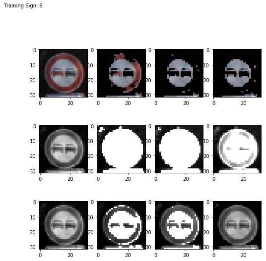

```python
import random

idx = random.randint(0,len(X_test))

img = X_test[idx].squeeze()
lbl = "Training Sign: {}".format(y_test[idx])

imageViz(img,lbl)
```

### Try RGB

```python
X_test.shape
```

```
(12630, 32, 32, 3)
```

```python
save_file = './rgbNet_10_001_100.ckpt'

# Global settings to be used across each implementation
outputFrequency = 1

# Get the images and labels
images = tf.placeholder(tf.float32,(None,32,32,3))
labels  = tf.placeholder(tf.int32,(None))
oneHotLabels = tf.one_hot(labels,43)
dropProb = tf.placeholder(tf.float32) # probability of keeping a node in

logits = myRGBNet(images, dropProb)
correctPrediction = tf.equal(tf.argmax(logits, 1), tf.argmax(oneHotLabels, 1))
accuracyOperation = tf.reduce_mean(tf.cast(correctPrediction, tf.float32))

# Launch the graph
with tf.Session() as sess:
    sess.run(tf.global_variables_initializer())
    saver = tf.train.import_meta_graph(save_file + '.meta')
    saver.restore(sess,save_file)

    test_accuracy = sess.run(accuracyOperation, feed_dict={images: X_test, labels: y_test, dropProb: 1.0})

print('Test Accuracy: {}'.format(test_accuracy))
```

```
Test Accuracy: 0.022961203008890152
```

### Try Greyscale

```python
import pickle

testing_file = 'data/test.p'

with open(testing_file, mode='rb') as f:
    test = pickle.load(f)

X_test, y_test = test['features'], test['labels']

# convert to greyscale
X_test = np.array([rgb2Grey(img, weights=[.299,.587,.114]) for img in X_test])

# Normalize the images - zero mean
X_test = np.array([np.array(normalizeGrey(img)) for img in X_test])



X_test = X_test.reshape((X_test.shape[0],32,32,1))
```

```python
X_test.shape
```

```
(12630, 32, 32, 1)
```

```python
save_file = './greyNet_10_001_100.ckpt'
#tf.reset_default_graph()
# Global settings to be used across each implementation
EPOCHS = 10
BATCH_SIZE = 128
LEARN_RATE = 0.001
DROP_PROB = 1.0

outputFrequency = 1

# Get the images and labels
images = tf.placeholder(tf.float32,(None,32,32,1))
labels  = tf.placeholder(tf.int32,(None))
oneHotLabels = tf.one_hot(labels,43)

logits = myGreyNet(images, DROP_PROB)#vgg16(images)#leNet(images)
crossEntropy = tf.nn.softmax_cross_entropy_with_logits(labels=oneHotLabels, logits=logits)
lossOperation = tf.reduce_mean(crossEntropy)
optimizer = tf.train.AdamOptimizer(learning_rate=LEARN_RATE)
trainingOperation = optimizer.minimize(lossOperation)
correctPrediction = tf.equal(tf.argmax(logits, 1), tf.argmax(oneHotLabels, 1))
accuracyOperation = tf.reduce_mean(tf.cast(correctPrediction, tf.float32))
#saver = tf.train.Saver()



# Launch the graph
with tf.Session() as sess:
    sess.run(tf.global_variables_initializer())
    saver = tf.train.import_meta_graph(save_file + '.meta')
    saver.restore(sess,save_file)
    #saver.restore(sess, save_file)
    #sess.run(tf.local_variables_initializer())

    test_accuracy = sess.run(accuracyOperation, feed_dict={images: X_test, labels: y_test})

print('Test Accuracy: {}'.format(test_accuracy))
```

```
Test Accuracy: 0.015914490446448326
```

### Try RGB + Greyscale

```python
import pickle

testing_file = 'data/test.p'

with open(testing_file, mode='rb') as f:
    test = pickle.load(f)

X_test, y_test = test['features'], test['labels']

# convert to rgb + greyscale - 4 channels (r,g,b,grey)
X_test = np.array([np.concatenate((img,np.array(rgb2Grey(img, weights=[.299,.587,.114])).reshape(32,32,1)),2) for img in X_test])

# Normalize the images - zero mean
X_test = np.array([np.array(normalizeRGBGrey(img)) for img in X_test])
```

```python
X_test.shape
```

```
(12630, 32, 32, 4)
```

```python
save_file = './rgbGreyNet_100_001_75.ckpt'
#tf.reset_default_graph()
# Global settings to be used across each implementation
EPOCHS = 10
BATCH_SIZE = 128
LEARN_RATE = 0.001
DROP_PROB = 1.0

outputFrequency = 1

# Get the images and labels
images = tf.placeholder(tf.float32,(None,32,32,4))
labels  = tf.placeholder(tf.int32,(None))
oneHotLabels = tf.one_hot(labels,43)

logits = myRGBGreyNet(images, DROP_PROB)#vgg16(images)#leNet(images)
crossEntropy = tf.nn.softmax_cross_entropy_with_logits(labels=oneHotLabels, logits=logits)
lossOperation = tf.reduce_mean(crossEntropy)
optimizer = tf.train.AdamOptimizer(learning_rate=LEARN_RATE)
trainingOperation = optimizer.minimize(lossOperation)
correctPrediction = tf.equal(tf.argmax(logits, 1), tf.argmax(oneHotLabels, 1))
accuracyOperation = tf.reduce_mean(tf.cast(correctPrediction, tf.float32))
#saver = tf.train.Saver()



# Launch the graph
with tf.Session() as sess:
    sess.run(tf.global_variables_initializer())
    saver = tf.train.import_meta_graph(save_file + '.meta')
    saver.restore(sess,save_file)
    #saver.restore(sess, save_file)
    #sess.run(tf.local_variables_initializer())

    test_accuracy = sess.run(accuracyOperation, feed_dict={images: X_test, labels: y_test})

print('Test Accuracy: {}'.format(test_accuracy))
```

```
Test Accuracy: 0.026603326201438904
```

### Analyze Performance

```python
### Calculate the accuracy for these 5 new images.
### For example, if the model predicted 1 out of 5 signs correctly, it's 20% accurate on these new images.
```

**COMMENTS**: The results from testing are in the test blocks.

I am having an issue restoring the models, where as when I test after training is complete then I get good results. See results in blocks where I trained models above please.

Please provide some guidance for restoring the models. What am I doing wrong?

Thank you!!!!

```python
# SEE COMMENTS ABOVE PLEASE
```

### Output Top 5 Softmax Probabilities For Each Image Found on the Web

For each of the new images, print out the model's softmax probabilities to show the **certainty** of the model's predictions (limit the output to the top 5 probabilities for each image). [`tf.nn.top_k`](https://www.tensorflow.org/versions/r0.12/api_docs/python/nn.html#top_k) could prove helpful here.

The example below demonstrates how tf.nn.top_k can be used to find the top k predictions for each image.

`tf.nn.top_k` will return the values and indices (class ids) of the top k predictions. So if k=3, for each sign, it'll return the 3 largest probabilities (out of a possible 43) and the correspoding class ids.

Take this numpy array as an example. The values in the array represent predictions. The array contains softmax probabilities for five candidate images with six possible classes. `tf.nn.top_k` is used to choose the three classes with the highest probability:

```
# (5, 6) array
a = np.array([[ 0.24879643,  0.07032244,  0.12641572,  0.34763842,  0.07893497,
         0.12789202],
       [ 0.28086119,  0.27569815,  0.08594638,  0.0178669 ,  0.18063401,
         0.15899337],
       [ 0.26076848,  0.23664738,  0.08020603,  0.07001922,  0.1134371 ,
         0.23892179],
       [ 0.11943333,  0.29198961,  0.02605103,  0.26234032,  0.1351348 ,
         0.16505091],
       [ 0.09561176,  0.34396535,  0.0643941 ,  0.16240774,  0.24206137,
         0.09155967]])
```

Running it through `sess.run(tf.nn.top_k(tf.constant(a), k=3))` produces:

```
TopKV2(values=array([[ 0.34763842,  0.24879643,  0.12789202],
       [ 0.28086119,  0.27569815,  0.18063401],
       [ 0.26076848,  0.23892179,  0.23664738],
       [ 0.29198961,  0.26234032,  0.16505091],
       [ 0.34396535,  0.24206137,  0.16240774]]), indices=array([[3, 0, 5],
       [0, 1, 4],
       [0, 5, 1],
       [1, 3, 5],
       [1, 4, 3]], dtype=int32))
```

Looking just at the first row we get `[ 0.34763842, 0.24879643, 0.12789202]`, you can confirm these are the 3 largest probabilities in `a`. You'll also notice `[3, 0, 5]` are the corresponding indices.

```python
### Print out the top five softmax probabilities for the predictions on the German traffic sign images found on the web.
### Feel free to use as many code cells as needed.
```

### Project Writeup

Once you have completed the code implementation, document your results in a project writeup using this [template](https://github.com/udacity/CarND-Traffic-Sign-Classifier-Project/blob/master/writeup_template.md) as a guide. The writeup can be in a markdown or pdf file.

## Step 4 (Optional): Visualize the Neural Network's State with Test Images

This Section is not required to complete but acts as an additional excersise for understaning the output of a neural network's weights. While neural networks can be a great learning device they are often referred to as a black box. We can understand what the weights of a neural network look like better by plotting their feature maps. After successfully training your neural network you can see what it's feature maps look like by plotting the output of the network's weight layers in response to a test stimuli image. From these plotted feature maps, it's possible to see what characteristics of an image the network finds interesting. For a sign, maybe the inner network feature maps react with high activation to the sign's boundary outline or to the contrast in the sign's painted symbol.

Provided for you below is the function code that allows you to get the visualization output of any tensorflow weight layer you want. The inputs to the function should be a stimuli image, one used during training or a new one you provided, and then the tensorflow variable name that represents the layer's state during the training process, for instance if you wanted to see what the LeNet lab's feature maps looked like for it's second convolutional layer you could enter conv2 as the tf_activation variable.

For an example of what feature map outputs look like, check out NVIDIA's results in their paper [End-to-End Deep Learning for Self-Driving Cars](https://devblogs.nvidia.com/parallelforall/deep-learning-self-driving-cars/) in the section Visualization of internal CNN State. NVIDIA was able to show that their network's inner weights had high activations to road boundary lines by comparing feature maps from an image with a clear path to one without. Try experimenting with a similar test to show that your trained network's weights are looking for interesting features, whether it's looking at differences in feature maps from images with or without a sign, or even what feature maps look like in a trained network vs a completely untrained one on the same sign image.

[figure not shown]

Your output should look something like this (above)

```python
### Visualize your network's feature maps here.
### Feel free to use as many code cells as needed.

# image_input: the test image being fed into the network to produce the feature maps
# tf_activation: should be a tf variable name used during your training procedure that represents the calculated state of a specific weight layer
# activation_min/max: can be used to view the activation contrast in more detail, by default matplot sets min and max to the actual min and max values of the output
# plt_num: used to plot out multiple different weight feature map sets on the same block, just extend the plt number for each new feature map entry

def outputFeatureMap(image_input, tf_activation, activation_min=-1, activation_max=-1 ,plt_num=1):
    # Here make sure to preprocess your image_input in a way your network expects
    # with size, normalization, ect if needed
    # image_input =
    # Note: x should be the same name as your network's tensorflow data placeholder variable
    # If you get an error tf_activation is not defined it may be having trouble accessing the variable from inside a function
    activation = tf_activation.eval(session=sess,feed_dict={x : image_input})
    featuremaps = activation.shape[3]
    plt.figure(plt_num, figsize=(15,15))
    for featuremap in range(featuremaps):
        plt.subplot(6,8, featuremap+1) # sets the number of feature maps to show on each row and column
        plt.title('FeatureMap ' + str(featuremap)) # displays the feature map number
        if activation_min != -1 & activation_max != -1:
            plt.imshow(activation[0,:,:, featuremap], interpolation="nearest", vmin =activation_min, vmax=activation_max, cmap="gray")
        elif activation_max != -1:
            plt.imshow(activation[0,:,:, featuremap], interpolation="nearest", vmax=activation_max, cmap="gray")
        elif activation_min !=-1:
            plt.imshow(activation[0,:,:, featuremap], interpolation="nearest", vmin=activation_min, cmap="gray")
        else:
            plt.imshow(activation[0,:,:, featuremap], interpolation="nearest", cmap="gray")
```